# Análisis para Práctica de desarrollo 2. PD02. Técnicas de ecología numérica, reproducibilidad

Elaborado por: José-Ramón Martínez-Batlle (jmartinez19@uasd.edu.do) Facultad de Ciencias, Universidad Autónoma de Santo Domingo (UASD) Santo Domingo, República Dominicana

## 0.1 Carga de paquetes

Son muchos los paquetes empleados en estos análisis. Puedes consultar en el ChatGPT qué hace cada uno. Considera un aspecto también importante: algunas funciones escritas por mí se cargan con `source_url` y `source`; dentro de algunas de dichas funciones, también se cargan paquetes adicionales.

```r
library(DT)
library(vegan)
library(sf)
library(tidyverse)
library(tmap)
library(kableExtra)
library(broom)
library(cluster)
library(gclus)
library(pvclust)
library(foreach)
library(leaps)
library(caret)
library(RColorBrewer)
library(indicspecies)
library(dendextend)
library(adespatial)
library(SpadeR)
library(iNEXT)
library(GGally)
library(vegetarian)

gh_content <- 'https://raw.githubusercontent.com/'
gh_zonal_stats <- paste0(
  gh_content,
  'geofis/zonal-statistics/0b2e95aaee87bf326cf132d28f4bd15220bb4ec7/out/')
repo_analisis <- 'biogeografia-master/scripts-de-analisis-BCI/master'
repo_sem202202 <- 'biogeografia-202202/material-de-apoyo/master/practicas/'
devtools::source_url(paste0(gh_content, repo_analisis, '/biodata/funciones.R'))
devtools::source_url(paste0(gh_content, repo_sem202202, 'train.R'))
devtools::source_url(paste0(gh_content, repo_sem202202, 'funciones.R'))
source('R/funciones.R')
source('matrices-de-comunidad-y-ambiental.R')
umbral_alfa <- 0.05
```

# 1 Análisis exploratorio de datos (AED)

## 1.1 Cargar la matriz de comunidad

```r
todos_los_objetos <- readRDS('salidas_RDS/todos_los_objetos_Acanthaceae.RDS')
mc <- todos_los_objetos$mc
mc %>% estilo_kable(
  titulo = 'Matriz de comunidad',
  nombres_filas = T, alinear = 'r')
```

Table 1.1: Matriz de comunidad

|  | Thunbergia alata Bojer ex Sims | Thunbergia fragrans Roxb. | Barleria lupulina Lindl. | Megaskepasma erythrochlamys Lindau | Justicia pilosella (Nees) Hilsenb. | Ruellia simplex C.Wright | Pachystachys lutea (Ruiz & Pav. ex Schult.) Nees | Thunbergia grandiflora (Roxb. ex Rottler) Roxb. | Odontonema cuspidatum (Nees) Kuntze | Asystasia gangetica (L.) T.Anderson | Ruellia ciliatiflora Hook. | Ruellia tuberosa L. | Ruellia coccinea (L.) Vahl | Ruellia blechum L. | Pachystachys spicata (Ruiz & Pav.) Wassh. | Barleriola solanifolia (L.) Oerst. ex Lindau | Oplonia spinosa (Jacq.) Raf. | Dianthera secunda (Lam.) Griseb. | Avicennia germinans (L.) L. | Andrographis paniculata (Burm.fil.) Nees | Dianthera pectoralis (Jacq.) J.F.Gmel. | Sanchezia parvibracteata Sprague & Hutch. | Crossandra infundibuliformis (L.) Nees | Graptophyllum pictum (L.) Griff. | Thunbergia erecta (Benth.) T.Anderson | Justicia brandegeeana Wassh. & L.B.Sm. | Dicliptera mucronata Urb. | Oplonia microphylla (Lam.) Stearn | Ruellia domingensis Spreng. ex Nees | … |
| --- | --- | --- | --- | --- | --- | --- | --- | --- | --- | --- | --- | --- | --- | --- | --- | --- | --- | --- | --- | --- | --- | --- | --- | --- | --- | --- | --- | --- | --- | --- |
| 854cd4cbfffffff | 1 | 1 | 0 | 1 | 0 | 1 | 0 | 1 | 1 | 0 | 0 | 0 | 0 | 0 | 0 | 0 | 0 | 0 | 0 | 0 | 0 | 0 | 1 | 0 | 1 | 0 | 0 | 0 | 1 | … |
| 854c8927fffffff | 1 | 1 | 0 | 0 | 0 | 0 | 1 | 0 | 0 | 0 | 0 | 1 | 0 | 0 | 0 | 0 | 0 | 0 | 0 | 0 | 0 | 0 | 1 | 0 | 0 | 0 | 0 | 0 | 0 | … |
| 85672537fffffff | 0 | 0 | 1 | 0 | 0 | 0 | 0 | 0 | 0 | 0 | 0 | 1 | 0 | 0 | 0 | 0 | 1 | 0 | 0 | 0 | 0 | 0 | 0 | 0 | 0 | 0 | 0 | 0 | 0 | … |
| 854c89abfffffff | 0 | 0 | 1 | 0 | 1 | 1 | 0 | 0 | 0 | 1 | 0 | 0 | 0 | 1 | 0 | 0 | 0 | 0 | 0 | 0 | 0 | 0 | 0 | 0 | 0 | 0 | 0 | 0 | 0 | … |
| 854c8933fffffff | 0 | 1 | 0 | 0 | 0 | 1 | 0 | 0 | 0 | 0 | 0 | 0 | 0 | 0 | 0 | 0 | 0 | 0 | 0 | 0 | 0 | 0 | 0 | 0 | 0 | 0 | 0 | 0 | 1 | … |
| 854c8997fffffff | 1 | 1 | 0 | 1 | 0 | 1 | 1 | 1 | 0 | 1 | 1 | 0 | 0 | 0 | 0 | 0 | 1 | 0 | 1 | 0 | 0 | 0 | 0 | 1 | 0 | 1 | 0 | 1 | 0 | … |
| 854cf247fffffff | 1 | 0 | 0 | 0 | 0 | 1 | 0 | 0 | 0 | 0 | 0 | 0 | 0 | 0 | 0 | 0 | 0 | 0 | 0 | 0 | 0 | 0 | 0 | 0 | 0 | 0 | 0 | 0 | 0 | … |
| 854cd29bfffffff | 0 | 0 | 0 | 0 | 0 | 0 | 0 | 0 | 1 | 0 | 0 | 0 | 1 | 0 | 0 | 1 | 0 | 0 | 0 | 0 | 1 | 0 | 0 | 0 | 0 | 0 | 0 | 0 | 0 | … |
| 854cd477fffffff | 1 | 0 | 0 | 1 | 0 | 0 | 0 | 1 | 0 | 0 | 0 | 0 | 0 | 0 | 0 | 0 | 0 | 0 | 0 | 0 | 0 | 0 | 1 | 0 | 0 | 0 | 0 | 0 | 0 | … |
| 854cd46bfffffff | 0 | 0 | 0 | 0 | 0 | 0 | 0 | 0 | 0 | 0 | 0 | 0 | 0 | 0 | 0 | 0 | 0 | 0 | 0 | 0 | 0 | 0 | 0 | 0 | 0 | 0 | 0 | 0 | 0 | … |
| 854c89b3fffffff | 1 | 1 | 0 | 1 | 0 | 0 | 1 | 0 | 1 | 0 | 0 | 1 | 0 | 0 | 0 | 0 | 0 | 1 | 0 | 0 | 0 | 0 | 0 | 0 | 0 | 0 | 0 | 0 | 0 | … |
| 854cd40bfffffff | 0 | 0 | 0 | 0 | 0 | 0 | 0 | 0 | 1 | 0 | 0 | 0 | 0 | 1 | 0 | 0 | 0 | 0 | 0 | 0 | 0 | 0 | 0 | 0 | 0 | 0 | 0 | 0 | 0 | … |
| 854cf373fffffff | 1 | 0 | 0 | 0 | 0 | 0 | 0 | 0 | 1 | 0 | 0 | 0 | 0 | 0 | 0 | 0 | 0 | 0 | 1 | 0 | 0 | 0 | 0 | 0 | 0 | 0 | 0 | 0 | 0 | … |
| 854cd423fffffff | 1 | 0 | 0 | 0 | 0 | 1 | 0 | 0 | 0 | 0 | 0 | 0 | 0 | 0 | 0 | 0 | 1 | 0 | 0 | 0 | 0 | 0 | 0 | 0 | 0 | 0 | 0 | 1 | 1 | … |
| 854cc6c7fffffff | 0 | 0 | 0 | 0 | 0 | 1 | 0 | 0 | 0 | 0 | 0 | 1 | 0 | 0 | 0 | 0 | 0 | 0 | 0 | 0 | 0 | 0 | 1 | 0 | 0 | 0 | 0 | 0 | 0 | … |
| 854c892ffffffff | 0 | 0 | 0 | 0 | 0 | 1 | 0 | 0 | 1 | 0 | 0 | 0 | 1 | 0 | 0 | 0 | 0 | 0 | 0 | 0 | 0 | 0 | 0 | 0 | 0 | 0 | 0 | 0 | 0 | … |
| 854cd63bfffffff | 0 | 0 | 0 | 0 | 0 | 0 | 0 | 0 | 0 | 0 | 1 | 0 | 0 | 0 | 0 | 0 | 0 | 0 | 0 | 0 | 0 | 0 | 0 | 0 | 0 | 0 | 1 | 0 | 0 | … |
| 854cd457fffffff | 0 | 0 | 0 | 0 | 0 | 0 | 0 | 1 | 0 | 0 | 0 | 0 | 0 | 0 | 1 | 0 | 0 | 0 | 0 | 0 | 0 | 0 | 0 | 0 | 0 | 0 | 0 | 0 | 0 | … |
| 856725b7fffffff | 0 | 0 | 0 | 1 | 0 | 1 | 0 | 0 | 0 | 1 | 0 | 0 | 0 | 0 | 0 | 1 | 1 | 0 | 0 | 0 | 0 | 0 | 0 | 0 | 0 | 0 | 0 | 0 | 0 | … |
| 854cf26ffffffff | 1 | 1 | 0 | 0 | 0 | 1 | 0 | 0 | 0 | 1 | 0 | 1 | 0 | 1 | 0 | 0 | 0 | 0 | 0 | 0 | 0 | 0 | 0 | 0 | 0 | 0 | 0 | 0 | 0 | … |
| 854c89a3fffffff | 0 | 0 | 1 | 0 | 0 | 1 | 0 | 1 | 1 | 0 | 0 | 1 | 0 | 0 | 0 | 0 | 0 | 0 | 0 | 0 | 0 | 0 | 0 | 1 | 0 | 0 | 0 | 0 | 0 | … |
| 854cd647fffffff | 0 | 0 | 0 | 0 | 0 | 1 | 0 | 0 | 0 | 0 | 0 | 1 | 0 | 0 | 0 | 0 | 0 | 0 | 0 | 0 | 0 | 0 | 0 | 0 | 0 | 0 | 0 | 0 | 0 | … |
| 854cd453fffffff | 1 | 0 | 0 | 0 | 0 | 0 | 0 | 1 | 1 | 0 | 0 | 0 | 0 | 0 | 0 | 0 | 0 | 0 | 0 | 0 | 0 | 0 | 0 | 0 | 0 | 0 | 0 | 0 | 0 | … |
| 854c89c7fffffff | 0 | 0 | 1 | 0 | 0 | 0 | 0 | 0 | 0 | 0 | 0 | 1 | 0 | 0 | 0 | 0 | 0 | 0 | 0 | 0 | 0 | 0 | 0 | 0 | 0 | 0 | 0 | 0 | 0 | … |
| 854c89c3fffffff | 0 | 0 | 1 | 0 | 0 | 0 | 0 | 0 | 0 | 0 | 0 | 0 | 0 | 0 | 0 | 0 | 0 | 0 | 0 | 0 | 0 | 0 | 0 | 0 | 0 | 0 | 0 | 0 | 0 | … |
| 854c8907fffffff | 0 | 0 | 0 | 0 | 1 | 0 | 0 | 0 | 0 | 0 | 0 | 0 | 0 | 0 | 0 | 0 | 0 | 0 | 0 | 0 | 0 | 0 | 0 | 0 | 0 | 0 | 0 | 0 | 0 | … |
| 854cf347fffffff | 1 | 0 | 0 | 0 | 0 | 0 | 0 | 0 | 0 | 0 | 0 | 0 | 1 | 0 | 0 | 0 | 0 | 0 | 1 | 0 | 0 | 0 | 0 | 0 | 0 | 0 | 0 | 0 | 0 | … |
| 854cd4bbfffffff | 0 | 0 | 0 | 1 | 0 | 0 | 0 | 0 | 1 | 0 | 0 | 0 | 0 | 0 | 0 | 0 | 0 | 0 | 0 | 0 | 0 | 0 | 0 | 0 | 0 | 0 | 0 | 0 | 0 | … |
| 854cf24bfffffff | 1 | 1 | 0 | 0 | 0 | 0 | 1 | 1 | 0 | 0 | 0 | 0 | 0 | 0 | 0 | 0 | 0 | 0 | 0 | 0 | 0 | 0 | 0 | 0 | 0 | 0 | 0 | 0 | 0 | … |
| 854cd0c3fffffff | 0 | 0 | 0 | 1 | 0 | 0 | 0 | 0 | 0 | 0 | 1 | 0 | 0 | 0 | 0 | 0 | 1 | 0 | 0 | 0 | 0 | 0 | 0 | 0 | 0 | 0 | 0 | 0 | 0 | … |

[output cut: 54 more lines]

Puede ser que sea un poco inabarcable mostrar la matriz de comunidad, porque podría tener muchas especies (cada columna es una especie de la familia elegida), en cuyo caso te recomiendo, sólo para fines de exploración pero NO para incluir en el manuscrito, que selecciones columnas al azar (el código siguiente selecciona 10 columnas).

```r
set.seed(99); mc[, sample(1:ncol(mc), 10)] %>% estilo_kable(
  titulo = 'Matriz de comunidad',
  nombres_filas = T, alinear = 'r')
```

Table 1.2: Matriz de comunidad

|  | Lepidagathis alopecuroidea (Vahl) R.Br. ex Griseb. | Sanchezia parvibracteata Sprague & Hutch. | Justicia alsinoides Leonard | Hygrophila costata Nees | Dianthera sessilis (Jacq.) J.F.Gmel. | Dyschoriste diffusa (Nees) Urb. | Ruellia coccinea (L.) Vahl | Andrographis paniculata (Burm.fil.) Nees | Barleriola inermis Urb. & Ekman | Megaskepasma erythrochlamys Lindau |
| --- | --- | --- | --- | --- | --- | --- | --- | --- | --- | --- |
| 854cd4cbfffffff | 0 | 0 | 0 | 1 | 0 | 0 | 0 | 0 | 0 | 1 |
| 854c8927fffffff | 0 | 0 | 0 | 0 | 0 | 0 | 0 | 0 | 0 | 0 |
| 85672537fffffff | 0 | 0 | 0 | 0 | 0 | 0 | 0 | 0 | 0 | 0 |
| 854c89abfffffff | 0 | 0 | 0 | 0 | 0 | 0 | 0 | 0 | 0 | 0 |
| 854c8933fffffff | 0 | 0 | 0 | 0 | 0 | 1 | 0 | 0 | 0 | 0 |
| 854c8997fffffff | 0 | 0 | 0 | 0 | 0 | 0 | 0 | 0 | 0 | 1 |
| 854cf247fffffff | 0 | 0 | 0 | 0 | 0 | 0 | 0 | 0 | 0 | 0 |
| 854cd29bfffffff | 0 | 0 | 0 | 0 | 0 | 0 | 1 | 0 | 0 | 0 |
| 854cd477fffffff | 0 | 0 | 0 | 0 | 0 | 0 | 0 | 0 | 0 | 1 |
| 854cd46bfffffff | 0 | 0 | 0 | 0 | 0 | 1 | 0 | 0 | 1 | 0 |
| 854c89b3fffffff | 0 | 0 | 0 | 0 | 0 | 0 | 0 | 0 | 0 | 1 |
| 854cd40bfffffff | 1 | 0 | 0 | 0 | 0 | 0 | 0 | 0 | 0 | 0 |
| 854cf373fffffff | 0 | 0 | 0 | 0 | 0 | 0 | 0 | 0 | 0 | 0 |
| 854cd423fffffff | 0 | 0 | 0 | 0 | 0 | 0 | 0 | 0 | 0 | 0 |
| 854cc6c7fffffff | 0 | 0 | 0 | 0 | 0 | 0 | 0 | 0 | 0 | 0 |
| 854c892ffffffff | 0 | 0 | 0 | 1 | 0 | 0 | 1 | 0 | 0 | 0 |
| 854cd63bfffffff | 0 | 0 | 0 | 0 | 0 | 0 | 0 | 0 | 0 | 0 |
| 854cd457fffffff | 0 | 0 | 0 | 1 | 0 | 0 | 0 | 0 | 0 | 0 |
| 856725b7fffffff | 0 | 0 | 0 | 0 | 0 | 1 | 0 | 0 | 0 | 1 |
| 854cf26ffffffff | 0 | 0 | 0 | 0 | 0 | 0 | 0 | 0 | 0 | 0 |
| 854c89a3fffffff | 0 | 0 | 0 | 0 | 0 | 0 | 0 | 0 | 0 | 0 |
| 854cd647fffffff | 0 | 0 | 0 | 0 | 0 | 0 | 0 | 0 | 0 | 0 |
| 854cd453fffffff | 1 | 0 | 1 | 0 | 0 | 0 | 0 | 0 | 0 | 0 |
| 854c89c7fffffff | 0 | 0 | 0 | 0 | 0 | 0 | 0 | 0 | 0 | 0 |
| 854c89c3fffffff | 0 | 0 | 0 | 0 | 0 | 1 | 0 | 0 | 0 | 0 |
| 854c8907fffffff | 0 | 0 | 0 | 0 | 0 | 0 | 0 | 0 | 0 | 0 |
| 854cf347fffffff | 0 | 0 | 0 | 0 | 0 | 0 | 1 | 0 | 0 | 0 |
| 854cd4bbfffffff | 0 | 0 | 0 | 0 | 0 | 0 | 0 | 0 | 0 | 1 |
| 854cf24bfffffff | 0 | 0 | 0 | 0 | 0 | 0 | 0 | 0 | 0 | 0 |
| 854cd0c3fffffff | 0 | 0 | 0 | 0 | 0 | 0 | 0 | 0 | 0 | 1 |

[output cut: 54 more lines]

Para fines de exploración, puedes usar la alternativa `mc %>% View()` para representarla en el visor de RStudio. Pero recuerda: no intentes colocar tablas grandes en el manuscrito, porque desbordarán el PDF y no serán legibles. Si una tabla es importante para el manuscrito, pero ocupa mucho espacio, puedes considerar incluirla en la sección de “Información suplementaria” del mismo.

Esta es la lista de especies mostrada en forma de tabla (específicamente, usando una función personalizada basada en el paquete `kableExtra`).

```r
lista_especies <- data.frame(Especies = sort(names(mc)))
lista_especies %>%
  estilo_kable(titulo = 'Lista de especies', cubre_anchura = F, alinear = 'c') %>%
  column_spec(column = 1, width = "15em")
```

Table 1.3: Lista de especies

| Especies |
| --- |
| Andrographis paniculata (Burm.fil.) Nees |
| Asystasia gangetica (L.) T.Anderson |
| Avicennia germinans (L.) L. |
| Barleria lupulina Lindl. |
| Barleriola inermis Urb. & Ekman |
| Barleriola solanifolia (L.) Oerst. ex Lindau |
| Crossandra infundibuliformis (L.) Nees |
| Dianthera pectoralis (Jacq.) J.F.Gmel. |
| Dianthera reptans (Sw.) J.F.Gmel. |
| Dianthera secunda (Lam.) Griseb. |
| Dianthera sessilis (Jacq.) J.F.Gmel. |
| Dicliptera mucronata Urb. |
| Dyschoriste diffusa (Nees) Urb. |
| Graptophyllum pictum (L.) Griff. |
| Hygrophila costata Nees |
| Justicia alsinoides Leonard |
| Justicia brandegeeana Wassh. & L.B.Sm. |
| Justicia disparifolia Urb. & Ekman |
| Justicia mirabiloides Lam. |
| Justicia pilosella (Nees) Hilsenb. |
| Lepidagathis alopecuroidea (Vahl) R.Br. ex Griseb. |
| Megaskepasma erythrochlamys Lindau |
| Odontonema cuspidatum (Nees) Kuntze |
| Oplonia acicularis (Sw.) Stearn |
| Oplonia microphylla (Lam.) Stearn |
| Oplonia spinosa (Jacq.) Raf. |
| Pachystachys lutea (Ruiz & Pav. ex Schult.) Nees |
| Pachystachys spicata (Ruiz & Pav.) Wassh. |
| Ruellia blechum L. |
| Ruellia ciliatiflora Hook. |
| Ruellia coccinea (L.) Vahl |
| Ruellia domingensis Spreng. ex Nees |
| Ruellia geminiflora Kunth |
| Ruellia lepidota Urb. |
| Ruellia simplex C.Wright |
| Ruellia tuberosa L. |
| Sanchezia parvibracteata Sprague & Hutch. |
| Stenandrium tuberosum (L.) Urb. |
| Thunbergia alata Bojer ex Sims |
| Thunbergia erecta (Benth.) T.Anderson |
| Thunbergia fragrans Roxb. |
| Thunbergia grandiflora (Roxb. ex Rottler) Roxb. |

Y esta el número de sitios (hexágonos H3) donde fue reportada cada especie

```r
num_sitios_especies <- data.frame(
  `Número de sitios donde fue reportada cada especie` = sort(colSums(mc), decreasing = T),
           check.names = F) %>%
  rownames_to_column('Especie')
num_sitios_especies %>%
  estilo_kable(
    titulo = paste('Número de sitios en los que está presente cada especie',
                   '(orden descendente por número de sitios)'),
    nombres_filas = F, alinear = 'cr')
```

Table 1.4: Número de sitios en los que está presente cada especie (orden descendente por número de sitios)

| Especie | Número de sitios donde fue reportada cada especie |
| --- | --- |
| Thunbergia alata Bojer ex Sims | 29 |
| Ruellia simplex C.Wright | 25 |
| Thunbergia fragrans Roxb. | 20 |
| Ruellia tuberosa L. | 20 |
| Thunbergia grandiflora (Roxb. ex Rottler) Roxb. | 19 |
| Odontonema cuspidatum (Nees) Kuntze | 17 |
| Asystasia gangetica (L.) T.Anderson | 15 |
| Ruellia blechum L. | 13 |
| Megaskepasma erythrochlamys Lindau | 10 |
| Oplonia spinosa (Jacq.) Raf. | 10 |
| Avicennia germinans (L.) L. | 10 |
| Barleria lupulina Lindl. | 9 |
| Ruellia coccinea (L.) Vahl | 9 |
| Crossandra infundibuliformis (L.) Nees | 8 |
| Pachystachys lutea (Ruiz & Pav. ex Schult.) Nees | 7 |
| Dyschoriste diffusa (Nees) Urb. | 7 |
| Lepidagathis alopecuroidea (Vahl) R.Br. ex Griseb. | 7 |
| Stenandrium tuberosum (L.) Urb. | 7 |
| Ruellia domingensis Spreng. ex Nees | 6 |
| Hygrophila costata Nees | 6 |
| Barleriola solanifolia (L.) Oerst. ex Lindau | 5 |
| Graptophyllum pictum (L.) Griff. | 5 |
| Oplonia microphylla (Lam.) Stearn | 5 |
| Justicia disparifolia Urb. & Ekman | 5 |
| Ruellia ciliatiflora Hook. | 4 |
| Justicia brandegeeana Wassh. & L.B.Sm. | 4 |
| Pachystachys spicata (Ruiz & Pav.) Wassh. | 3 |
| Sanchezia parvibracteata Sprague & Hutch. | 3 |
| Barleriola inermis Urb. & Ekman | 3 |
| Ruellia lepidota Urb. | 3 |
| Justicia pilosella (Nees) Hilsenb. | 2 |
| Dianthera secunda (Lam.) Griseb. | 2 |
| Andrographis paniculata (Burm.fil.) Nees | 2 |
| Dianthera pectoralis (Jacq.) J.F.Gmel. | 2 |
| Dicliptera mucronata Urb. | 2 |
| Justicia alsinoides Leonard | 2 |
| Justicia mirabiloides Lam. | 2 |
| Dianthera sessilis (Jacq.) J.F.Gmel. | 2 |
| Dianthera reptans (Sw.) J.F.Gmel. | 2 |
| Thunbergia erecta (Benth.) T.Anderson | 1 |
| Ruellia geminiflora Kunth | 1 |
| Oplonia acicularis (Sw.) Stearn | 1 |

La tabla es grande, porque tiene tanta filas como especies. Un extracto podría ser útil en el manuscrito (siempre que lo cites dentro del mismo), por ejemplo, las primeras 10 filas ordenadas descendentemente por número de sitios.

```r
num_sitios_especies %>%
  slice_head(n = 10) %>%
  estilo_kable(
    titulo = paste('Número de sitios en los que estás presentes las 10 especies más comunes',
                   '(orden descendente por número de sitios)'),
    nombres_filas = F, alinear = 'cr')
```

Table 1.5: Número de sitios en los que estás presentes las 10 especies más comunes (orden descendente por número de sitios)

| Especie | Número de sitios donde fue reportada cada especie |
| --- | --- |
| Thunbergia alata Bojer ex Sims | 29 |
| Ruellia simplex C.Wright | 25 |
| Thunbergia fragrans Roxb. | 20 |
| Ruellia tuberosa L. | 20 |
| Thunbergia grandiflora (Roxb. ex Rottler) Roxb. | 19 |
| Odontonema cuspidatum (Nees) Kuntze | 17 |
| Asystasia gangetica (L.) T.Anderson | 15 |
| Ruellia blechum L. | 13 |
| Megaskepasma erythrochlamys Lindau | 10 |
| Oplonia spinosa (Jacq.) Raf. | 10 |

También se puede obtener la riqueza de especies por sitios.

```r
riqueza_por_sitios <- data.frame(`Riqueza por sitios` = rowSums(mc),
           check.names = F) %>%  rownames_to_column('Sitio') %>%
  arrange(desc(`Riqueza por sitios`))
riqueza_por_sitios %>%
  estilo_kable(
    titulo = 'Riqueza por sitios (orden descendente por riqueza)',
    nombres_filas = F, alinear = 'cr')
```

Table 1.6: Riqueza por sitios (orden descendente por riqueza)

| Sitio | Riqueza por sitios |
| --- | --- |
| 854c8997fffffff | 13 |
| 854cd4cbfffffff | 11 |
| 854cf243fffffff | 11 |
| 854cd42ffffffff | 10 |
| 854cd427fffffff | 8 |
| 854c898ffffffff | 8 |
| 854c89b3fffffff | 7 |
| 854cd453fffffff | 7 |
| 854cd5b7fffffff | 7 |
| 854c8927fffffff | 6 |
| 854cd423fffffff | 6 |
| 856725b7fffffff | 6 |
| 854cf26ffffffff | 6 |
| 854c89a3fffffff | 6 |
| 854c89abfffffff | 5 |
| 854cd29bfffffff | 5 |
| 854cd457fffffff | 5 |
| 854cf31bfffffff | 5 |
| 854cd667fffffff | 5 |
| 854c8933fffffff | 4 |
| 854cd477fffffff | 4 |
| 854cd40bfffffff | 4 |
| 854c892ffffffff | 4 |
| 854cf347fffffff | 4 |
| 854cf24bfffffff | 4 |
| 854cd0c3fffffff | 4 |
| 854cd5b3fffffff | 4 |
| 854cf20ffffffff | 4 |
| 854cc6cffffffff | 4 |
| 854cc613fffffff | 4 |

[output cut: 54 more lines]

Al igual que en casos anteriores, esta tabla podría desbordar la salida, pues en este caso tiene muchas filas. Puedes incluir este tipo de tablas-resumen en tu manucrito siempre que lo consideres relevante en tu texto (tabla que se incluya en el manuscrito, tabla que necesita referencia en el texto). Un buen extracto podría ser seleccionar las primeras filas (sólo lo insertarías en tu manuscrito si lo refieres debidamente); por ejemplo, las primeras 10 filas ordenadas descendentemente en función de la riqueza por sitios, no parecen desbordar mucho el PDF en mi caso.

```r
riqueza_por_sitios %>%
  slice_head(n = 10) %>%
  estilo_kable(
    titulo = 'Número de especies en los 10 sitios de mayor riqueza (orden descendente por riqueza)',
    nombres_filas = F, alinear = 'cr')
```

Table 1.7: Número de especies en los 10 sitios de mayor riqueza (orden descendente por riqueza)

| Sitio | Riqueza por sitios |
| --- | --- |
| 854c8997fffffff | 13 |
| 854cd4cbfffffff | 11 |
| 854cf243fffffff | 11 |
| 854cd42ffffffff | 10 |
| 854cd427fffffff | 8 |
| 854c898ffffffff | 8 |
| 854c89b3fffffff | 7 |
| 854cd453fffffff | 7 |
| 854cd5b7fffffff | 7 |
| 854c8927fffffff | 6 |

La matriz de comunidad analizada se compone de 84 sitios y 42 especies, donde el/los sitio/s más ricos es/son 854c8997fffffff. La/s especie/s más común/es es/son Thunbergia alata Bojer ex Sims y la/s más rara/s es/son Thunbergia erecta (Benth.) T.Anderson, Ruellia geminiflora Kunth y Oplonia acicularis (Sw.) Stearn. El siguiente gráfico de mosaicos muestra la distribución de las especies según sitios.

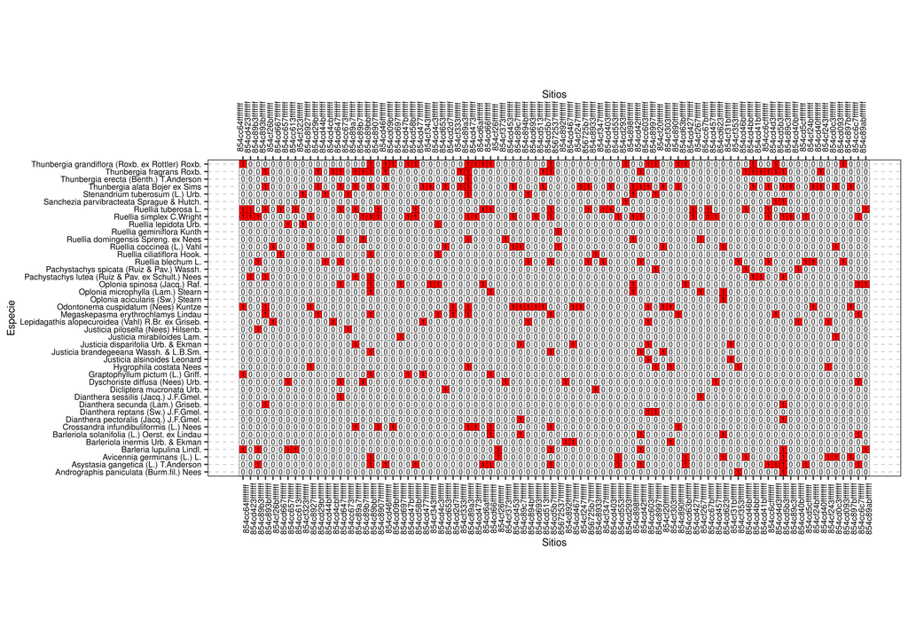

Figure 1.1: Distribución de las especies según sitios

```r
grafico_mosaico <- crear_grafico_mosaico_de_mc(mc, tam_rotulo = 8) + xlab('Sitios') + ylab('Especie')
grafico_mosaico
```

Si los rótulos del gráfico se superpponen o son ilegibles, puedes probar a exportar el gráfico con este código, integrarlo donde sea conveniente (ver párrafos posteriores):

```r
jpeg('grafico_mosaico.jpg', width = 4000, height = 2200, res = 350)
grafico_mosaico
graphics.off()
```

Revisa el archivo `grafico_mosaico.jpg` y verifica si luce bien. Si luce bien, lo puedes llevar a tu manuscrito. Juega con los argumentos `width`, `height` y `res` para ajustar el tamaño y la resolución del gráfico.

> ¡¡¡IMPORTANTE!!! Si estás ejecutando código interactivamente, no olvides ejecutar `graphics.off()` después de ejecutar `jpeg...` y `grafico_mosaico`, pues de lo contrario, el dispositivo gráfico quedará abierto en el archivo JPEG creado, y no se mostrarán más gráficos a continuación en la ventana gráfica.

Puedes insertar tu figura de múltiples formas. En la PD01 expliqué al menos dos formas. Esta es una de las que más control te ofrece sobre el gráfico.

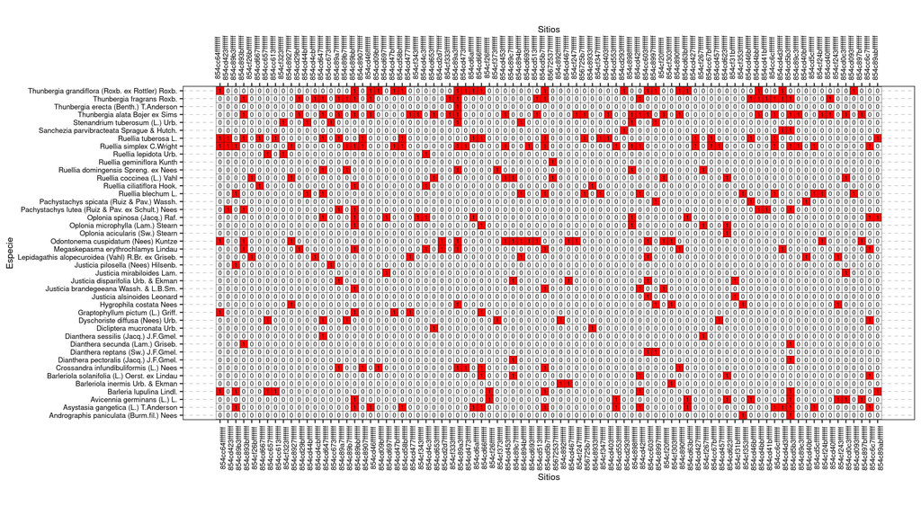

(#fig:grafico_mosaico)Distribución de las especies (presencia/ausencia) según sitios

Si tu familia elegida tiene muchas especies, o las especies están presentes en muchos sitios, el gráfico de mosaico podría no ser legible aun cambiando la resolución, anchura y altura. En ese caso, luego de probar opciones, consúltame para que intentemos colocar debidamente en tu manuscrito.

Puedes también generar otros gráficos. En `todos_los_objetos` se encuentran, como su nombre lo indica, todos los objetos creados por el *toolchain* del cuaderno `matrices-de-comunidad-y-ambiental.Rmd` que creé para ti. Uno de ellos consiste en un mapa de distribución de los registros de presencia de GBIF para el taxón, y los hexágonos de la biblioteca H3.

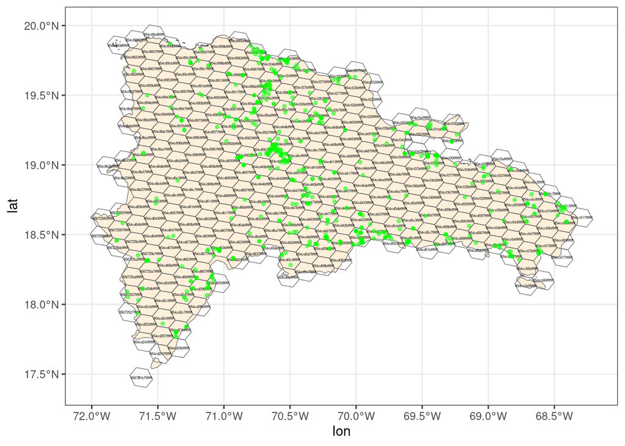

```r
# Mapa
todos_los_objetos$aoi_reg_hex_inter_g
```

Si notas que los elementos se empastan, prueba crear un JPEG conteniendo el mapa y ajusta el tamaño y la resolución del gráfico, tal como te mostré para el gráfico de mosaico. Si el mapa se ve bien, podrías usar el objeto `todos_los_objetos$aoi_reg_hex_inter_g` para llevarlo a tu manuscrito.

## 1.2 Transformar la matriz de comunidad

Este paso es importante, lo explico [aquí](https://www.youtube.com/watch?v=yQ10lp0-nHc&list=PLDcT2n8UzsCRDqjqSeqHI1wsiNOqpYmsJ&index=10)

```r
mc_t <- decostand(mc, 'hellinger') #Hellinger, funciona con datos de presencia/ausencia
mc_t %>% estilo_kable(titulo = 'Matriz de comunidad transformada',
                      nombres_filas = T, alinear = 'r')
```

Table 1.8: Matriz de comunidad transformada

|  | Thunbergia alata Bojer ex Sims | Thunbergia fragrans Roxb. | Barleria lupulina Lindl. | Megaskepasma erythrochlamys Lindau | Justicia pilosella (Nees) Hilsenb. | Ruellia simplex C.Wright | Pachystachys lutea (Ruiz & Pav. ex Schult.) Nees | Thunbergia grandiflora (Roxb. ex Rottler) Roxb. | Odontonema cuspidatum (Nees) Kuntze | Asystasia gangetica (L.) T.Anderson | Ruellia ciliatiflora Hook. | Ruellia tuberosa L. | Ruellia coccinea (L.) Vahl | Ruellia blechum L. | Pachystachys spicata (Ruiz & Pav.) Wassh. | Barleriola solanifolia (L.) Oerst. ex Lindau | Oplonia spinosa (Jacq.) Raf. | Dianthera secunda (Lam.) Griseb. | Avicennia germinans (L.) L. | Andrographis paniculata (Burm.fil.) Nees | Dianthera pectoralis (Jacq.) J.F.Gmel. | Sanchezia parvibracteata Sprague & Hutch. | Crossandra infundibuliformis (L.) Nees | Graptophyllum pictum (L.) Griff. | Thunbergia erecta (Benth.) T.Anderson | Justicia brandegeeana Wassh. & L.B.Sm. | Dicliptera mucronata Urb. | Oplonia microphylla (Lam.) Stearn | Ruellia domingensis Spreng. ex Nees | … |
| --- | --- | --- | --- | --- | --- | --- | --- | --- | --- | --- | --- | --- | --- | --- | --- | --- | --- | --- | --- | --- | --- | --- | --- | --- | --- | --- | --- | --- | --- | --- |
| 854cd4cbfffffff | 0.30 | 0.30 | 0.00 | 0.30 | 0.00 | 0.30 | 0.00 | 0.30 | 0.30 | 0.00 | 0.00 | 0.00 | 0.00 | 0.00 | 0.00 | 0.00 | 0.00 | 0.00 | 0.00 | 0.00 | 0.00 | 0.00 | 0.30 | 0.00 | 0.3 | 0.00 | 0.00 | 0.00 | 0.30 | … |
| 854c8927fffffff | 0.41 | 0.41 | 0.00 | 0.00 | 0.00 | 0.00 | 0.41 | 0.00 | 0.00 | 0.00 | 0.00 | 0.41 | 0.00 | 0.00 | 0.00 | 0.00 | 0.00 | 0.00 | 0.00 | 0.00 | 0.00 | 0.00 | 0.41 | 0.00 | 0.0 | 0.00 | 0.00 | 0.00 | 0.00 | … |
| 85672537fffffff | 0.00 | 0.00 | 0.58 | 0.00 | 0.00 | 0.00 | 0.00 | 0.00 | 0.00 | 0.00 | 0.00 | 0.58 | 0.00 | 0.00 | 0.00 | 0.00 | 0.58 | 0.00 | 0.00 | 0.00 | 0.00 | 0.00 | 0.00 | 0.00 | 0.0 | 0.00 | 0.00 | 0.00 | 0.00 | … |
| 854c89abfffffff | 0.00 | 0.00 | 0.45 | 0.00 | 0.45 | 0.45 | 0.00 | 0.00 | 0.00 | 0.45 | 0.00 | 0.00 | 0.00 | 0.45 | 0.00 | 0.00 | 0.00 | 0.00 | 0.00 | 0.00 | 0.00 | 0.00 | 0.00 | 0.00 | 0.0 | 0.00 | 0.00 | 0.00 | 0.00 | … |
| 854c8933fffffff | 0.00 | 0.50 | 0.00 | 0.00 | 0.00 | 0.50 | 0.00 | 0.00 | 0.00 | 0.00 | 0.00 | 0.00 | 0.00 | 0.00 | 0.00 | 0.00 | 0.00 | 0.00 | 0.00 | 0.00 | 0.00 | 0.00 | 0.00 | 0.00 | 0.0 | 0.00 | 0.00 | 0.00 | 0.50 | … |
| 854c8997fffffff | 0.28 | 0.28 | 0.00 | 0.28 | 0.00 | 0.28 | 0.28 | 0.28 | 0.00 | 0.28 | 0.28 | 0.00 | 0.00 | 0.00 | 0.00 | 0.00 | 0.28 | 0.00 | 0.28 | 0.00 | 0.00 | 0.00 | 0.00 | 0.28 | 0.0 | 0.28 | 0.00 | 0.28 | 0.00 | … |
| 854cf247fffffff | 0.71 | 0.00 | 0.00 | 0.00 | 0.00 | 0.71 | 0.00 | 0.00 | 0.00 | 0.00 | 0.00 | 0.00 | 0.00 | 0.00 | 0.00 | 0.00 | 0.00 | 0.00 | 0.00 | 0.00 | 0.00 | 0.00 | 0.00 | 0.00 | 0.0 | 0.00 | 0.00 | 0.00 | 0.00 | … |
| 854cd29bfffffff | 0.00 | 0.00 | 0.00 | 0.00 | 0.00 | 0.00 | 0.00 | 0.00 | 0.45 | 0.00 | 0.00 | 0.00 | 0.45 | 0.00 | 0.00 | 0.45 | 0.00 | 0.00 | 0.00 | 0.00 | 0.45 | 0.00 | 0.00 | 0.00 | 0.0 | 0.00 | 0.00 | 0.00 | 0.00 | … |
| 854cd477fffffff | 0.50 | 0.00 | 0.00 | 0.50 | 0.00 | 0.00 | 0.00 | 0.50 | 0.00 | 0.00 | 0.00 | 0.00 | 0.00 | 0.00 | 0.00 | 0.00 | 0.00 | 0.00 | 0.00 | 0.00 | 0.00 | 0.00 | 0.50 | 0.00 | 0.0 | 0.00 | 0.00 | 0.00 | 0.00 | … |
| 854cd46bfffffff | 0.00 | 0.00 | 0.00 | 0.00 | 0.00 | 0.00 | 0.00 | 0.00 | 0.00 | 0.00 | 0.00 | 0.00 | 0.00 | 0.00 | 0.00 | 0.00 | 0.00 | 0.00 | 0.00 | 0.00 | 0.00 | 0.00 | 0.00 | 0.00 | 0.0 | 0.00 | 0.00 | 0.00 | 0.00 | … |
| 854c89b3fffffff | 0.38 | 0.38 | 0.00 | 0.38 | 0.00 | 0.00 | 0.38 | 0.00 | 0.38 | 0.00 | 0.00 | 0.38 | 0.00 | 0.00 | 0.00 | 0.00 | 0.00 | 0.38 | 0.00 | 0.00 | 0.00 | 0.00 | 0.00 | 0.00 | 0.0 | 0.00 | 0.00 | 0.00 | 0.00 | … |
| 854cd40bfffffff | 0.00 | 0.00 | 0.00 | 0.00 | 0.00 | 0.00 | 0.00 | 0.00 | 0.50 | 0.00 | 0.00 | 0.00 | 0.00 | 0.50 | 0.00 | 0.00 | 0.00 | 0.00 | 0.00 | 0.00 | 0.00 | 0.00 | 0.00 | 0.00 | 0.0 | 0.00 | 0.00 | 0.00 | 0.00 | … |
| 854cf373fffffff | 0.58 | 0.00 | 0.00 | 0.00 | 0.00 | 0.00 | 0.00 | 0.00 | 0.58 | 0.00 | 0.00 | 0.00 | 0.00 | 0.00 | 0.00 | 0.00 | 0.00 | 0.00 | 0.58 | 0.00 | 0.00 | 0.00 | 0.00 | 0.00 | 0.0 | 0.00 | 0.00 | 0.00 | 0.00 | … |
| 854cd423fffffff | 0.41 | 0.00 | 0.00 | 0.00 | 0.00 | 0.41 | 0.00 | 0.00 | 0.00 | 0.00 | 0.00 | 0.00 | 0.00 | 0.00 | 0.00 | 0.00 | 0.41 | 0.00 | 0.00 | 0.00 | 0.00 | 0.00 | 0.00 | 0.00 | 0.0 | 0.00 | 0.00 | 0.41 | 0.41 | … |
| 854cc6c7fffffff | 0.00 | 0.00 | 0.00 | 0.00 | 0.00 | 0.58 | 0.00 | 0.00 | 0.00 | 0.00 | 0.00 | 0.58 | 0.00 | 0.00 | 0.00 | 0.00 | 0.00 | 0.00 | 0.00 | 0.00 | 0.00 | 0.00 | 0.58 | 0.00 | 0.0 | 0.00 | 0.00 | 0.00 | 0.00 | … |
| 854c892ffffffff | 0.00 | 0.00 | 0.00 | 0.00 | 0.00 | 0.50 | 0.00 | 0.00 | 0.50 | 0.00 | 0.00 | 0.00 | 0.50 | 0.00 | 0.00 | 0.00 | 0.00 | 0.00 | 0.00 | 0.00 | 0.00 | 0.00 | 0.00 | 0.00 | 0.0 | 0.00 | 0.00 | 0.00 | 0.00 | … |
| 854cd63bfffffff | 0.00 | 0.00 | 0.00 | 0.00 | 0.00 | 0.00 | 0.00 | 0.00 | 0.00 | 0.00 | 0.71 | 0.00 | 0.00 | 0.00 | 0.00 | 0.00 | 0.00 | 0.00 | 0.00 | 0.00 | 0.00 | 0.00 | 0.00 | 0.00 | 0.0 | 0.00 | 0.71 | 0.00 | 0.00 | … |
| 854cd457fffffff | 0.00 | 0.00 | 0.00 | 0.00 | 0.00 | 0.00 | 0.00 | 0.45 | 0.00 | 0.00 | 0.00 | 0.00 | 0.00 | 0.00 | 0.45 | 0.00 | 0.00 | 0.00 | 0.00 | 0.00 | 0.00 | 0.00 | 0.00 | 0.00 | 0.0 | 0.00 | 0.00 | 0.00 | 0.00 | … |
| 856725b7fffffff | 0.00 | 0.00 | 0.00 | 0.41 | 0.00 | 0.41 | 0.00 | 0.00 | 0.00 | 0.41 | 0.00 | 0.00 | 0.00 | 0.00 | 0.00 | 0.41 | 0.41 | 0.00 | 0.00 | 0.00 | 0.00 | 0.00 | 0.00 | 0.00 | 0.0 | 0.00 | 0.00 | 0.00 | 0.00 | … |
| 854cf26ffffffff | 0.41 | 0.41 | 0.00 | 0.00 | 0.00 | 0.41 | 0.00 | 0.00 | 0.00 | 0.41 | 0.00 | 0.41 | 0.00 | 0.41 | 0.00 | 0.00 | 0.00 | 0.00 | 0.00 | 0.00 | 0.00 | 0.00 | 0.00 | 0.00 | 0.0 | 0.00 | 0.00 | 0.00 | 0.00 | … |
| 854c89a3fffffff | 0.00 | 0.00 | 0.41 | 0.00 | 0.00 | 0.41 | 0.00 | 0.41 | 0.41 | 0.00 | 0.00 | 0.41 | 0.00 | 0.00 | 0.00 | 0.00 | 0.00 | 0.00 | 0.00 | 0.00 | 0.00 | 0.00 | 0.00 | 0.41 | 0.0 | 0.00 | 0.00 | 0.00 | 0.00 | … |
| 854cd647fffffff | 0.00 | 0.00 | 0.00 | 0.00 | 0.00 | 0.71 | 0.00 | 0.00 | 0.00 | 0.00 | 0.00 | 0.71 | 0.00 | 0.00 | 0.00 | 0.00 | 0.00 | 0.00 | 0.00 | 0.00 | 0.00 | 0.00 | 0.00 | 0.00 | 0.0 | 0.00 | 0.00 | 0.00 | 0.00 | … |
| 854cd453fffffff | 0.38 | 0.00 | 0.00 | 0.00 | 0.00 | 0.00 | 0.00 | 0.38 | 0.38 | 0.00 | 0.00 | 0.00 | 0.00 | 0.00 | 0.00 | 0.00 | 0.00 | 0.00 | 0.00 | 0.00 | 0.00 | 0.00 | 0.00 | 0.00 | 0.0 | 0.00 | 0.00 | 0.00 | 0.00 | … |
| 854c89c7fffffff | 0.00 | 0.00 | 0.71 | 0.00 | 0.00 | 0.00 | 0.00 | 0.00 | 0.00 | 0.00 | 0.00 | 0.71 | 0.00 | 0.00 | 0.00 | 0.00 | 0.00 | 0.00 | 0.00 | 0.00 | 0.00 | 0.00 | 0.00 | 0.00 | 0.0 | 0.00 | 0.00 | 0.00 | 0.00 | … |
| 854c89c3fffffff | 0.00 | 0.00 | 0.58 | 0.00 | 0.00 | 0.00 | 0.00 | 0.00 | 0.00 | 0.00 | 0.00 | 0.00 | 0.00 | 0.00 | 0.00 | 0.00 | 0.00 | 0.00 | 0.00 | 0.00 | 0.00 | 0.00 | 0.00 | 0.00 | 0.0 | 0.00 | 0.00 | 0.00 | 0.00 | … |
| 854c8907fffffff | 0.00 | 0.00 | 0.00 | 0.00 | 0.71 | 0.00 | 0.00 | 0.00 | 0.00 | 0.00 | 0.00 | 0.00 | 0.00 | 0.00 | 0.00 | 0.00 | 0.00 | 0.00 | 0.00 | 0.00 | 0.00 | 0.00 | 0.00 | 0.00 | 0.0 | 0.00 | 0.00 | 0.00 | 0.00 | … |
| 854cf347fffffff | 0.50 | 0.00 | 0.00 | 0.00 | 0.00 | 0.00 | 0.00 | 0.00 | 0.00 | 0.00 | 0.00 | 0.00 | 0.50 | 0.00 | 0.00 | 0.00 | 0.00 | 0.00 | 0.50 | 0.00 | 0.00 | 0.00 | 0.00 | 0.00 | 0.0 | 0.00 | 0.00 | 0.00 | 0.00 | … |
| 854cd4bbfffffff | 0.00 | 0.00 | 0.00 | 0.71 | 0.00 | 0.00 | 0.00 | 0.00 | 0.71 | 0.00 | 0.00 | 0.00 | 0.00 | 0.00 | 0.00 | 0.00 | 0.00 | 0.00 | 0.00 | 0.00 | 0.00 | 0.00 | 0.00 | 0.00 | 0.0 | 0.00 | 0.00 | 0.00 | 0.00 | … |
| 854cf24bfffffff | 0.50 | 0.50 | 0.00 | 0.00 | 0.00 | 0.00 | 0.50 | 0.50 | 0.00 | 0.00 | 0.00 | 0.00 | 0.00 | 0.00 | 0.00 | 0.00 | 0.00 | 0.00 | 0.00 | 0.00 | 0.00 | 0.00 | 0.00 | 0.00 | 0.0 | 0.00 | 0.00 | 0.00 | 0.00 | … |
| 854cd0c3fffffff | 0.00 | 0.00 | 0.00 | 0.50 | 0.00 | 0.00 | 0.00 | 0.00 | 0.00 | 0.00 | 0.50 | 0.00 | 0.00 | 0.00 | 0.00 | 0.00 | 0.50 | 0.00 | 0.00 | 0.00 | 0.00 | 0.00 | 0.00 | 0.00 | 0.0 | 0.00 | 0.00 | 0.00 | 0.00 | … |

[output cut: 54 more lines]

```r
# Otras transformaciones posibles con datos de presencia/ausencia
# mc_t <- decostand(mc, 'normalize') #Chord
# mc_t <- decostand(log1p(mc), 'normalize') #Chord
# mc_t <- decostand(mc, 'chi.square') #Chi-square
```

## 1.3 Cargar la matriz ambiental

```r
env <- todos_los_objetos$ma
env %>% estilo_kable(titulo = 'Matriz ambiental', nombres_filas = T, alinear = 'r')
```

Table 1.9: Matriz ambiental

|  | ESA Trees | ESA Shrubland | ESA Grassland | ESA Cropland | ESA Built-up | ESA Barren / sparse vegetation | ESA Open water | ESA Herbaceous wetland | ESA Mangroves | CGL Closed forest, evergreen needle leaf | CGL Closed forest, evergreen broad leaf | CGL Closed forest, deciduous broad leaf | CGL Closed forest, mixed | CGL Closed forest, not matching any of the other definitions | CGL Open forest, evergreen needle leaf | CGL Open forest, evergreen broad leaf | CGL Open forest, deciduous broad leaf | CGL Open forest, mixed | CGL Open forest, not matching any of the other definitions | CGL Shrubs | CGL Oceans, seas | CGL Herbaceous vegetation | CGL Cultivated and managed vegetation / agriculture | CGL Urban / built up | CGL Bare / sparse vegetation | CGL Permanent water bodies | CGL Herbaceous wetland | GSL Peak/ridge (warm) | GSL Peak/ridge | … |
| --- | --- | --- | --- | --- | --- | --- | --- | --- | --- | --- | --- | --- | --- | --- | --- | --- | --- | --- | --- | --- | --- | --- | --- | --- | --- | --- | --- | --- | --- | --- |
| 854cd4cbfffffff | 85.32 | 0.02 | 13.50 | 0.09 | 0.94 | 0.08 | 0.03 | 0.02 | 0.00 | 0.00 | 54.44 | 0.00 | 1.71 | 1.27 | 0 | 12.71 | 0.00 | 0.00 | 24.61 | 0.98 | 0.00 | 3.33 | 0.01 | 0.92 | 0.00 | 0.01 | 0.02 | 2.95 | 0.00 | … |
| 854c8927fffffff | 74.81 | 0.02 | 22.32 | 0.08 | 2.74 | 0.03 | 0.00 | 0.00 | 0.00 | 0.00 | 29.53 | 0.00 | 7.93 | 0.95 | 0 | 17.57 | 0.00 | 0.00 | 36.22 | 0.83 | 0.00 | 3.51 | 0.01 | 3.45 | 0.00 | 0.00 | 0.00 | 4.08 | 0.01 | … |
| 85672537fffffff | 51.64 | 25.44 | 15.77 | 0.55 | 1.96 | 0.25 | 2.63 | 0.76 | 1.00 | 0.00 | 5.15 | 0.41 | 0.00 | 2.72 | 0 | 1.52 | 0.18 | 0.00 | 27.27 | 47.16 | 1.65 | 5.65 | 2.53 | 2.49 | 0.00 | 0.90 | 2.37 | 0.35 | 0.00 | … |
| 854c89abfffffff | 46.54 | 4.68 | 34.13 | 5.42 | 8.44 | 0.77 | 0.02 | 0.00 | 0.00 | 0.00 | 3.68 | 0.17 | 0.03 | 0.47 | 0 | 2.80 | 0.51 | 0.00 | 49.34 | 15.69 | 0.00 | 10.96 | 6.79 | 9.52 | 0.00 | 0.00 | 0.02 | 2.26 | 0.01 | … |
| 854c8933fffffff | 55.97 | 0.10 | 39.43 | 0.06 | 0.97 | 0.06 | 3.37 | 0.03 | 0.00 | 0.00 | 11.26 | 0.10 | 0.66 | 1.70 | 0 | 11.15 | 0.55 | 0.00 | 66.03 | 0.61 | 0.00 | 4.05 | 0.22 | 1.06 | 0.00 | 2.02 | 0.59 | 7.31 | 0.01 | … |
| 854c8997fffffff | 53.23 | 0.18 | 16.10 | 0.05 | 5.32 | 0.30 | 24.41 | 0.04 | 0.37 | 0.00 | 17.58 | 0.02 | 1.14 | 2.25 | 0 | 3.55 | 0.03 | 0.00 | 37.24 | 0.49 | 23.26 | 5.93 | 0.43 | 6.28 | 0.00 | 0.86 | 0.92 | 4.37 | 0.01 | … |
| 854cf247fffffff | 48.25 | 0.07 | 24.22 | 0.31 | 1.11 | 0.27 | 19.88 | 3.45 | 2.45 | 0.00 | 15.25 | 0.11 | 1.12 | 1.30 | 0 | 2.10 | 0.00 | 0.00 | 24.34 | 4.25 | 19.74 | 24.66 | 0.78 | 1.77 | 0.00 | 0.07 | 4.51 | 1.47 | 0.00 | … |
| 854cd29bfffffff | 92.63 | 0.45 | 6.86 | 0.00 | 0.02 | 0.04 | 0.00 | 0.00 | 0.00 | 0.00 | 54.67 | 0.08 | 6.62 | 0.85 | 0 | 16.43 | 0.09 | 0.00 | 18.53 | 2.57 | 0.00 | 0.14 | 0.00 | 0.00 | 0.00 | 0.00 | 0.00 | 2.27 | 0.00 | … |
| 854cd477fffffff | 77.78 | 0.01 | 18.68 | 1.13 | 2.25 | 0.14 | 0.02 | 0.00 | 0.00 | 0.00 | 44.34 | 0.00 | 0.00 | 1.13 | 0 | 13.80 | 0.00 | 0.00 | 29.68 | 0.70 | 0.00 | 6.91 | 0.49 | 2.95 | 0.00 | 0.00 | 0.00 | 3.76 | 0.10 | … |
| 854cd46bfffffff | 77.23 | 0.29 | 19.60 | 0.65 | 1.81 | 0.24 | 0.18 | 0.00 | 0.00 | 0.00 | 37.40 | 2.84 | 1.28 | 2.29 | 0 | 9.61 | 2.38 | 0.00 | 38.21 | 1.87 | 0.00 | 1.90 | 0.30 | 1.86 | 0.00 | 0.00 | 0.07 | 4.49 | 0.15 | … |
| 854c89b3fffffff | 83.01 | 0.00 | 16.78 | 0.00 | 0.21 | 0.00 | 0.00 | 0.00 | 0.00 | 0.00 | 31.13 | 0.00 | 0.52 | 0.43 | 0 | 15.86 | 0.00 | 0.00 | 43.14 | 0.48 | 0.00 | 8.32 | 0.00 | 0.12 | 0.00 | 0.00 | 0.00 | 4.71 | 0.24 | … |
| 854cd40bfffffff | 69.87 | 0.21 | 23.01 | 3.42 | 1.77 | 1.67 | 0.03 | 0.01 | 0.00 | 0.00 | 38.21 | 0.00 | 0.10 | 0.91 | 0 | 10.21 | 0.00 | 0.00 | 34.36 | 2.77 | 0.00 | 8.14 | 2.80 | 1.87 | 0.00 | 0.00 | 0.64 | 5.37 | 0.15 | … |
| 854cf373fffffff | 69.55 | 0.00 | 21.94 | 2.55 | 1.52 | 0.01 | 2.34 | 0.32 | 1.78 | 0.00 | 12.05 | 0.08 | 0.00 | 2.04 | 0 | 8.19 | 0.00 | 0.00 | 54.31 | 3.29 | 1.85 | 12.83 | 0.84 | 2.01 | 0.00 | 0.37 | 2.14 | 3.15 | 0.00 | … |
| 854cd423fffffff | 51.80 | 0.03 | 39.96 | 0.25 | 7.44 | 0.49 | 0.01 | 0.02 | 0.00 | 0.00 | 9.56 | 0.00 | 0.00 | 1.23 | 0 | 4.98 | 0.00 | 0.00 | 56.12 | 1.27 | 0.00 | 18.53 | 0.95 | 7.36 | 0.00 | 0.00 | 0.00 | 1.85 | 0.01 | … |
| 854cc6c7fffffff | 15.63 | 0.00 | 18.05 | 0.01 | 1.04 | 0.62 | 60.88 | 2.23 | 1.55 | 0.00 | 1.59 | 0.00 | 0.00 | 1.79 | 0 | 0.15 | 0.00 | 0.00 | 6.90 | 1.49 | 63.16 | 22.10 | 0.50 | 0.72 | 0.00 | 0.05 | 1.55 | 0.00 | 0.00 | … |
| 854c892ffffffff | 93.43 | 0.21 | 6.05 | 0.13 | 0.17 | 0.01 | 0.00 | 0.00 | 0.00 | 0.00 | 43.30 | 0.00 | 38.47 | 0.56 | 0 | 8.70 | 0.00 | 0.02 | 7.46 | 0.31 | 0.00 | 1.12 | 0.00 | 0.06 | 0.00 | 0.00 | 0.00 | 3.40 | 0.03 | … |
| 854cd63bfffffff | 60.04 | 37.59 | 2.17 | 0.01 | 0.01 | 0.18 | 0.00 | 0.00 | 0.00 | 0.00 | 29.90 | 0.29 | 2.77 | 1.15 | 0 | 7.34 | 0.19 | 0.00 | 42.22 | 16.04 | 0.00 | 0.05 | 0.05 | 0.00 | 0.00 | 0.00 | 0.00 | 3.29 | 0.00 | … |
| 854cd457fffffff | 80.56 | 0.08 | 10.17 | 2.08 | 6.50 | 0.53 | 0.07 | 0.02 | 0.00 | 0.00 | 39.05 | 0.00 | 0.73 | 0.48 | 0 | 12.05 | 0.00 | 0.00 | 32.29 | 2.42 | 0.00 | 4.42 | 1.40 | 7.09 | 0.00 | 0.00 | 0.08 | 2.74 | 0.17 | … |
| 856725b7fffffff | 23.13 | 44.74 | 16.62 | 2.11 | 1.34 | 4.47 | 7.09 | 0.49 | 0.00 | 0.00 | 6.03 | 0.00 | 0.00 | 0.15 | 0 | 4.68 | 0.00 | 0.00 | 26.63 | 45.64 | 0.00 | 2.02 | 0.77 | 1.00 | 0.16 | 8.97 | 3.96 | 2.30 | 0.00 | … |
| 854cf26ffffffff | 79.36 | 0.01 | 13.07 | 0.36 | 7.18 | 0.02 | 0.00 | 0.00 | 0.00 | 0.00 | 33.81 | 0.00 | 0.00 | 2.78 | 0 | 11.76 | 0.00 | 0.00 | 32.19 | 2.57 | 0.00 | 7.12 | 2.18 | 7.58 | 0.00 | 0.00 | 0.00 | 2.13 | 0.00 | … |
| 854c89a3fffffff | 50.18 | 0.15 | 14.80 | 2.05 | 32.19 | 0.62 | 0.01 | 0.00 | 0.00 | 0.00 | 4.10 | 0.00 | 0.00 | 0.27 | 0 | 3.21 | 0.00 | 0.00 | 23.75 | 6.74 | 0.00 | 13.80 | 7.14 | 40.98 | 0.00 | 0.00 | 0.00 | 1.08 | 0.00 | … |
| 854cd647fffffff | 67.99 | 10.22 | 16.95 | 1.26 | 2.60 | 0.94 | 0.00 | 0.05 | 0.00 | 0.00 | 17.29 | 0.55 | 0.50 | 2.76 | 0 | 9.28 | 0.29 | 0.00 | 28.90 | 32.88 | 0.00 | 3.94 | 0.27 | 3.20 | 0.00 | 0.00 | 0.14 | 1.31 | 0.00 | … |
| 854cd453fffffff | 87.57 | 0.02 | 11.22 | 0.73 | 0.43 | 0.04 | 0.00 | 0.00 | 0.00 | 0.00 | 54.35 | 0.00 | 8.13 | 1.03 | 0 | 15.12 | 0.02 | 0.01 | 18.95 | 0.50 | 0.00 | 1.78 | 0.00 | 0.11 | 0.00 | 0.00 | 0.00 | 5.70 | 0.03 | … |
| 854c89c7fffffff | 27.48 | 30.03 | 32.40 | 5.64 | 2.27 | 2.13 | 0.05 | 0.00 | 0.00 | 0.00 | 0.87 | 0.00 | 0.00 | 0.16 | 0 | 1.38 | 0.00 | 0.00 | 34.28 | 30.86 | 0.00 | 17.02 | 13.14 | 2.24 | 0.00 | 0.02 | 0.02 | 0.87 | 0.00 | … |
| 854c89c3fffffff | 19.51 | 31.38 | 46.36 | 0.32 | 0.67 | 1.02 | 0.07 | 0.04 | 0.64 | 0.00 | 7.02 | 0.08 | 0.00 | 0.94 | 0 | 5.18 | 0.10 | 0.00 | 40.68 | 19.38 | 0.00 | 15.24 | 10.43 | 0.31 | 0.00 | 0.01 | 0.64 | 4.89 | 0.02 | … |
| 854c8907fffffff | 66.37 | 6.22 | 26.20 | 0.23 | 0.94 | 0.04 | 0.00 | 0.00 | 0.00 | 0.00 | 13.65 | 0.22 | 0.49 | 3.24 | 0 | 14.65 | 0.20 | 0.00 | 55.78 | 5.61 | 0.00 | 4.71 | 0.67 | 0.77 | 0.00 | 0.00 | 0.00 | 3.28 | 0.01 | … |
| 854cf347fffffff | 35.28 | 0.00 | 0.96 | 0.00 | 0.00 | 0.01 | 63.23 | 0.09 | 0.42 | 0.00 | 33.16 | 0.00 | 0.00 | 0.27 | 0 | 1.23 | 0.00 | 0.00 | 1.67 | 0.00 | 61.76 | 0.06 | 0.00 | 0.00 | 0.00 | 1.00 | 0.85 | 5.20 | 0.00 | … |
| 854cd4bbfffffff | 52.72 | 0.00 | 46.30 | 0.56 | 0.43 | 0.00 | 0.00 | 0.00 | 0.00 | 0.00 | 12.76 | 0.00 | 0.00 | 0.48 | 0 | 7.70 | 0.00 | 0.00 | 52.54 | 0.54 | 0.00 | 25.29 | 0.09 | 0.60 | 0.00 | 0.00 | 0.00 | 2.99 | 0.00 | … |
| 854cf24bfffffff | 57.65 | 0.01 | 29.54 | 0.05 | 3.48 | 0.20 | 8.60 | 0.27 | 0.20 | 0.00 | 10.81 | 0.00 | 0.43 | 0.46 | 0 | 5.04 | 0.00 | 0.00 | 35.97 | 7.32 | 7.85 | 22.50 | 4.01 | 4.35 | 0.00 | 0.57 | 0.67 | 2.15 | 0.00 | … |
| 854cd0c3fffffff | 34.15 | 40.46 | 15.39 | 2.55 | 1.50 | 3.35 | 2.60 | 0.00 | 0.00 | 0.00 | 0.00 | 0.00 | 0.00 | 0.00 | 0 | 0.08 | 0.00 | 0.00 | 29.63 | 59.25 | 1.91 | 1.89 | 3.97 | 1.34 | 1.08 | 0.59 | 0.25 | 3.90 | 0.13 | … |

[output cut: 54 more lines]

Al igual que la matriz de comunidad, la ambiental tiene muchas columnas y filas. E, igualmente, no te recomiendo que la incluyas en el documento de manuscrito. Puedes seleccionar columnas al azar o de manera específica usando el índice de columnas (por ejemplo, `colnames(env)`), o usar la alternativa `env %>% View()` para representarla en el visor de RStudio.

La matriz ambiental se compone de 140 variables de tipo numérico, conteniendo el valor de cada variable para cada uno de los 84 sitios. La siguiente tabla y el gráfico muestran un resumen de los estadísticos básicos de la matriz ambiental.

```r
estad_basicos <- env %>%
  pivot_longer(everything(), names_to = "Variable", values_to = "Valor") %>%
  group_by(Variable) %>%
  summarise(
    Media = mean(Valor),
    Mediana = median(Valor),
    `Desv. Estándar` = sd(Valor),
    Varianza = var(Valor),
    `Error Estándar` = sd(Valor) / sqrt(length(Valor)))
estad_basicos %>% estilo_kable(titulo = 'Matriz ambiental', nombres_filas = F, alinear = 'crrrr')
```

Table 1.10: Matriz ambiental

| Variable | Media | Mediana | Desv. Estándar | Varianza | Error Estándar |
| --- | --- | --- | --- | --- | --- |
| CGIAR-ELE mean | 365.91 | 236.67 | 399.90 | 1.599195e+05 | 43.63 |
| CGL Bare / sparse vegetation | 0.02 | 0.00 | 0.12 | 1.000000e-02 | 0.01 |
| CGL Closed forest, deciduous broad leaf | 0.16 | 0.00 | 0.56 | 3.100000e-01 | 0.06 |
| CGL Closed forest, evergreen broad leaf | 22.23 | 16.73 | 19.40 | 3.762200e+02 | 2.12 |
| CGL Closed forest, evergreen needle leaf | 0.01 | 0.00 | 0.05 | 0.000000e+00 | 0.01 |
| CGL Closed forest, mixed | 2.32 | 0.03 | 7.24 | 5.243000e+01 | 0.79 |
| CGL Closed forest, not matching any of the other definitions | 1.29 | 1.04 | 1.25 | 1.570000e+00 | 0.14 |
| CGL Cultivated and managed vegetation / agriculture | 3.37 | 0.58 | 7.37 | 5.427000e+01 | 0.80 |
| CGL Herbaceous vegetation | 10.68 | 7.19 | 11.65 | 1.356500e+02 | 1.27 |
| CGL Herbaceous wetland | 0.80 | 0.15 | 1.72 | 2.970000e+00 | 0.19 |
| CGL Oceans, seas | 10.30 | 0.00 | 20.70 | 4.284600e+02 | 2.26 |
| CGL Open forest, deciduous broad leaf | 0.17 | 0.00 | 0.60 | 3.600000e-01 | 0.07 |
| CGL Open forest, evergreen broad leaf | 7.41 | 6.48 | 5.93 | 3.519000e+01 | 0.65 |
| CGL Open forest, evergreen needle leaf | 0.00 | 0.00 | 0.00 | 0.000000e+00 | 0.00 |
| CGL Open forest, mixed | 0.00 | 0.00 | 0.00 | 0.000000e+00 | 0.00 |
| CGL Open forest, not matching any of the other definitions | 28.97 | 28.55 | 15.06 | 2.267100e+02 | 1.64 |
| CGL Permanent water bodies | 0.54 | 0.00 | 1.18 | 1.400000e+00 | 0.13 |
| CGL Shrubs | 7.24 | 2.37 | 11.67 | 1.362000e+02 | 1.27 |
| CGL Urban / built up | 4.51 | 1.02 | 10.40 | 1.082500e+02 | 1.14 |
| CH-BIO bio01 mean annual air temperature | 2971.03 | 2979.50 | 24.47 | 5.986000e+02 | 2.67 |
| CH-BIO bio02 mean diurnal air temperature range | 69.85 | 74.54 | 20.15 | 4.060500e+02 | 2.20 |
| CH-BIO bio03 isothermality | 647.57 | 667.60 | 55.16 | 3.042770e+03 | 6.02 |
| CH-BIO bio04 temperature seasonality | 1213.73 | 1172.75 | 177.29 | 3.143343e+04 | 19.34 |
| CH-BIO bio05 mean daily maximum air temperature of the warmest month | 3025.52 | 3026.36 | 25.28 | 6.389600e+02 | 2.76 |
| CH-BIO bio06 mean daily minimum air temperature of the coldest month | 2919.48 | 2918.17 | 30.74 | 9.451500e+02 | 3.35 |
| CH-BIO bio07 annual range of air temperature | 106.04 | 108.42 | 24.98 | 6.240700e+02 | 2.73 |
| CH-BIO bio08 mean daily mean air temperatures of the wettest quarter | 2976.86 | 2981.47 | 24.14 | 5.829200e+02 | 2.63 |
| CH-BIO bio09 mean daily mean air temperatures of the driest quarter | 2959.67 | 2970.01 | 27.54 | 7.587200e+02 | 3.01 |
| CH-BIO bio10 mean daily mean air temperatures of the warmest quarter | 2985.45 | 2996.39 | 24.75 | 6.126800e+02 | 2.70 |
| CH-BIO bio11 mean daily mean air temperatures of the coldest quarter | 2954.85 | 2960.67 | 25.02 | 6.260200e+02 | 2.73 |

[output cut: 110 more lines]

Se muestra a continuación un diagrama de cajas que sólo incluye un grupo de variables ambientales. Son muchas variables ambientales, y si se incluyen todas, el servidor no aguantaría o el gráfico no sería legible. Es por ello que ves el comando `select(matches('^ESA'))`, el cual selecciona las columnas que comienzan por la cadena de caracteres ‘ESA’. El Sufijo de grupo “^ESA”, que se refiere a los datos de cobertura del suelo de la Agencia Espacial Europea (ESA 2021, imágenes Sentinel 1 y Sentinel 2 a 10 m de resolucion máximo). Se deben hacer gráficos para otros grupos de variables, ver la lista de grupos posibles en la columna “Sufijo del grupo” de la Tabla 1 de [este HTML](https://geofis.github.io/zonal-statistics/README.html). Otros grupos posibles son CGL, GSL, GHH, WCL, CH-BIO, G90, G90-GEOM, CGIAR-ELE, GFC-PTC, GFC-LOSS, OSM-DIST, GP-CONSUNadj, YINSOLTIME, WBW-DIST, TSEASON-IZZO y PSEASON-IZZO. ES IMPRESCINDIBLE que visites el enlace anterior por dos razones: 1) Para que te ayude a comprender mejor las múltiples variables disponibles y cómo fueron estas derivadas; 2) Para que puedas citar debidamente cada fuente usada, pues no deberías quedarte sólo en citar mi repo, sino también, las fuentes originales.

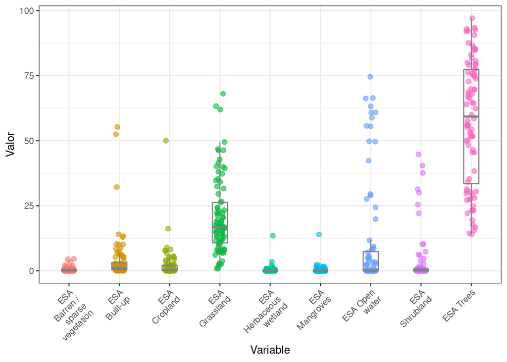

```r
env %>%
  select(matches('^ESA')) %>%
  pivot_longer(everything(), names_to = 'Variable', values_to = 'Valor') %>%
  group_by(Variable) %>%
  ggplot() +
  aes(x = Variable, y = Valor, color = Variable, fill = Variable) +
  # geom_boxplot(lwd = 0.2) +
  geom_violin(alpha = 0.2, width = 0.8, color = "transparent") +
  geom_jitter(alpha = 0.6, size = 2, height = 0, width = 0.1) +
  geom_boxplot(alpha = 0, width = 0.3, color = "#808080") +
  scale_fill_brewer(palette = 'Set1') +
  scale_x_discrete(labels = function(x) str_wrap(x, width = 10)) +  # Aplica str_wrap
  theme_bw() +
  theme(legend.position="none",
        axis.text.x = element_text(angle = 45, hjust = 1))
```

A continuación, realizaré análisis de agrupamiento, ordenación y diversidad, basándome en las indicaciones de Borcard, Gillet, y Legendre (2018), reaprovechando el código contenido en Martínez Batlle (2020).

# 2 Análisis de agrupamiento

A continuación, el **análisis de agrupamiento** propiamente. La parte más importante es generar un árbol, a partir de una matriz de distancias, que haga sentido desde el punto de vista de la comunidad y la distribución de las especies. Primero cargaré paquetes específicos de esta técnica y generaré la matriz de distancias.

```r
mc_d <- vegdist(mc_t, "euc")
```

## 2.1 Generación de árboles

A continuación, generaré árboles usando distintos métodos. Explico detalladamente estas técnicas en el [repo](https://github.com/biogeografia-master/scripts-de-analisis-BCI), y en los vídeos (13 a 16) de la lista mencionada arriba [“Ecología Numérica con R” de mi canal](https://www.youtube.com/playlist?list=PLDcT2n8UzsCRDqjqSeqHI1wsiNOqpYmsJ).

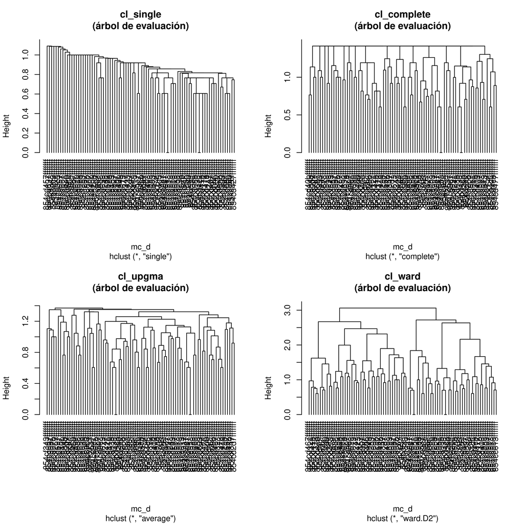

```r
lista_cl <- list(
        cl_single = hclust(mc_d, method = 'single'),
        cl_complete = hclust(mc_d, method = 'complete'),
        cl_upgma = hclust(mc_d, method = 'average'),
        cl_ward = hclust(mc_d, method = 'ward.D2')
)
par(mfrow = c(2,2))
invisible(map(names(lista_cl), function(x) plot(lista_cl[[x]], main = paste0(x, '\n(árbol de evaluación)'), hang = -1)))
```

```r
par(mfrow = c(1,1))
```

Es probable que el árbol anterior no sea legible, o que se produzca un error si estás ejecutando código en la consola. En ese caso, te recomiendo que intentes guardar el árbol como archivo JPEG, y así lo podrás ver con claridad. Esto se haría de la misma forma que hice con el gráfico de mosaicos:

```r
jpeg('arboles_todos.jpg', width = 4000, height = 2200, res = 350)
par(mfrow = c(2,2))
invisible(
  map(names(lista_cl),
      function(x)
        plot(lista_cl[[x]], main = paste0(x, '\n(árbol de evaluación)'), hang = -1)))
graphics.off()
```

Para insertarlo, uso este bloque de código (nota que me refiero a Acanthaceae en el título o “*caption*”, pero debes editar):

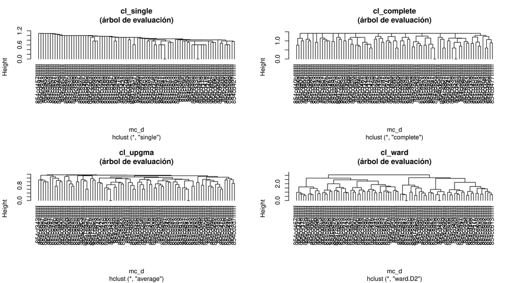

(#fig:arboles_todos)Agrupamiento jerárquico de sitios (hexágonos H3) en función de su riqueza de especies de Acanthaceae

A continuación, **calcularé la distancia y la correlación cofenéticas; esta última, la correlación cofenética, se emplea como criterio flexible para elegir el método de agrupamiento idóneo, pero no debe usarse de manera estricta**. Se supone que el método con la mayor correlación cofenética explica mejor el agrupamiento de la comunidad. Si quieres comprender mejor esta técnica, consulta el vídeo que te referí en el párrafo anterior, así como los libros de referencia. Normalmente, el método UPGMA obtiene la mayor correlación cofenética, pero esto se debe a que su procedimiento de obtención maximiza precisamente dicha métrica. No es recomendable conservar un único método de agrupamiento, normalmente es bueno usar al menos dos. Ward es muchas veces recomendado como método de contraste, por basarse en procedimientos de cálculo muy distintos a los de UPGMA.

```r
map_df(lista_cl, function(x) {
        coph_d <- cophenetic(x)
        corr <- cor(mc_d, coph_d)
        return(corr)
}) %>% t() %>% as.data.frame() %>%
  rownames_to_column %>%
  mutate(rowname = gsub('cl_', '', rowname)) %>%
  setNames(c('Método de agrupamiento', 'Correlación cofenética')) %>%
  estilo_kable()
```

Table 2.1:

| Método de agrupamiento | Correlación cofenética |
| --- | --- |
| single | 0.48 |
| complete | 0.57 |
| upgma | 0.66 |
| ward | 0.47 |

## 2.2 Anchura de siluetas

Ahora, calcularé **las anchuras de siluetas, una métrica que ayuda a determinar en cuántos grupos se organiza la comunidad; las anchuras de silueta no deben usarse como método estricto, y sólo debe usarse de forma flexible para informarnos sobre el número máximo de grupos posibles**. Considera las siguientes reglas:

- El número ideal es 3 grupos, de 4 a 5 grupos es aceptable, 6 o más grupos se considera difícil de interpretar, o es un resultado poco útil; 1 grupo es un resultado sin sentido.
- Si obtienes distintos grupos, **pero uno o varios están compuestos por un único sitio, observa qué ocurre en ese sitio**, pues es probable que contenga especie raras sólo presentes en él. En este caso, es recomendable explorar dos alternativas para evitar el grupo formado por un único sitio: ver qué ocurre usando distintos métodos o elegir cortar el árbol en un número de grupos menor.

### 2.2.1 Anchuras de siluetas para el método UPGMA

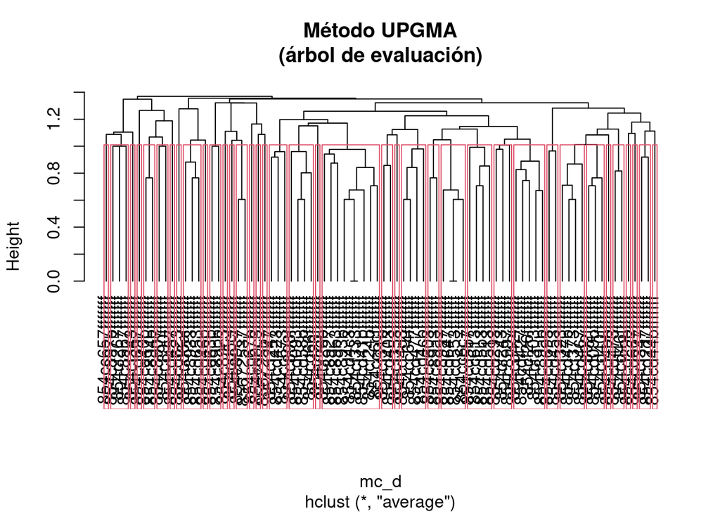

```r
# UPGMA
anch_sil_upgma <- calcular_anchuras_siluetas(
        mc_orig = mc,
        distancias = mc_d,
        cluster = lista_cl$cl_upgma)
u_dend_reord <- reorder.hclust(lista_cl$cl_upgma, mc_d)
plot(u_dend_reord, hang = -1, main = 'Método UPGMA\n(árbol de evaluación)')
rect.hclust(
        tree = u_dend_reord,
        k = anch_sil_upgma$n_grupos_optimo)
```

```r
resultado_evaluacion_upgma <- evaluar_arbol(u_dend_reord, anch_sil_upgma$n_grupos_optimo)
```

Tras cortar el árbol, la evaluación practicada concluyó lo siguiente: **“Árbol útil para análisis posteriores, siempre que se corte en 6 grupos”**.

### 2.2.2 Anchuras de siluetas para el método Ward

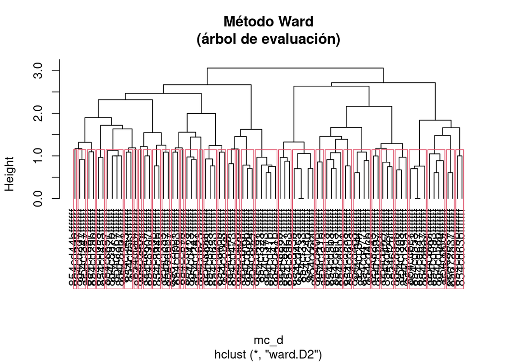

```r
# Ward
anch_sil_ward <- calcular_anchuras_siluetas(
        mc_orig = mc,
        distancias = mc_d,
        cluster = lista_cl$cl_ward)
w_dend_reord <- reorder.hclust(lista_cl$cl_ward, mc_d)
plot(w_dend_reord, hang = -1, main = 'Método Ward\n(árbol de evaluación)')
rect.hclust(
        tree = w_dend_reord,
        k = anch_sil_ward$n_grupos_optimo)
```

```r
resultado_evaluacion_ward <- evaluar_arbol(w_dend_reord, anch_sil_ward$n_grupos_optimo)
```

Tras cortar el árbol, la evaluación practicada concluyó lo siguiente: “Árbol útil para análisis posteriores, siempre que se corte en 11 grupos”.

Observa cómo se comporta el agrupamiento con otros métodos de evaluación, como el remuestreo por *bootstrap* multiescalar.

## 2.3 Remuestreo por *bootstrap* multiescalar

Una forma alterna de evaluar árboles consiste en usar el remuestreo por *bootstrap* multiescalar. No me interesa que profundices en ella, sólo presentártela como técnica probabilística para evaluar árboles generados por métodos determinísticos. La técnica es documentada en Borcard, Gillet, y Legendre (2018), de la cual puedes un resumen en [este cuaderno](https://github.com/biogeografia-master/scripts-de-analisis-BCI/blob/master/aa_analisis_de_agrupamiento_2_intepretacion_resultados.md#evaluaci%C3%B3n-mediante-remuestreo-por-bootstrap-multiescalar) y en [este vídeo (minuto 51:33)](https://youtu.be/y1ZZh9ajT_U?list=PLDcT2n8UzsCRDqjqSeqHI1wsiNOqpYmsJ&t=3093). El remuestreo por *bootstrap* multiescalar valida la robustez de los análisis de agrupamiento tomando múltiples muestras aleatorias de los datos en diferentes tamaños. Este proceso determina qué grupos son consistentemente identificados como clústeres, generando valores de probabilidad aproximadamente insesgados (AU) que son considerados más fiables que las probabilidades de *bootstrap* tradicionales (BP). Esta técnica ayuda a identificar y confirmar patrones robustos en los datos.

Lo aplicaré primero al árbol generado por el método UPGMA.

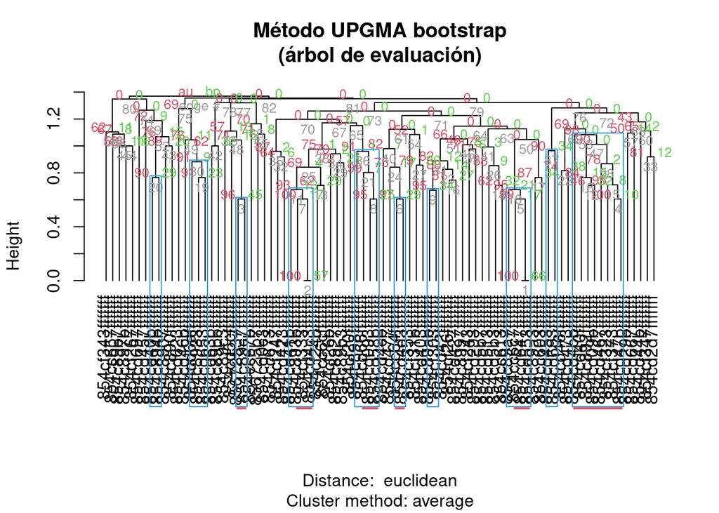

```r
# UPGMA
# if(interactive()) dev.new()
cl_pvclust_upgma <-
        pvclust(t(mc_t),
                method.hclust = "average",
                method.dist = "euc",
                iseed = 99, # Resultado reproducible
                parallel = TRUE, quiet = TRUE)
# Añadir los valores de p
plot(cl_pvclust_upgma, hang = -1, main = 'Método UPGMA bootstrap\n(árbol de evaluación)')
# Añadir rectángulos a los grupos significativos
lines(cl_pvclust_upgma)
pvrect(cl_pvclust_upgma, alpha = 0.90, border = 4)
```

> Nota: al igual que en casos anteriores, si el gráfico es ilegible, opta por convertirlo a JPEG.

Lo aplicaré también al árbol generado por el método Ward.

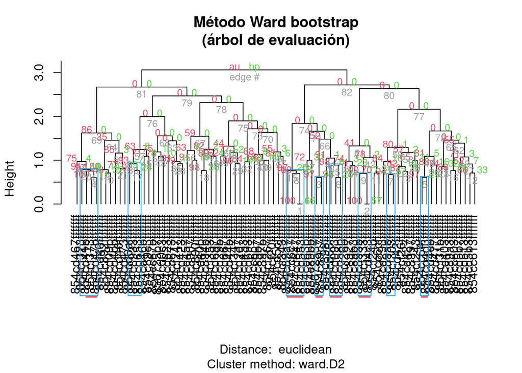

```r
# Ward
# if(interactive()) dev.new()
cl_pvclust_ward <-
        pvclust(t(mc_t),
                method.hclust = "ward.D2",
                method.dist = "euc",
                iseed = 99, # Resultado reproducible
                parallel = TRUE, quiet = TRUE)
# Añadir los valores de p
plot(cl_pvclust_ward, hang = -1, main = 'Método Ward bootstrap\n(árbol de evaluación)')
# Añadir rectángulos a los grupos significativos
lines(cl_pvclust_ward)
pvrect(cl_pvclust_ward, alpha = 0.91, border = 4)
```

## 2.4 Conclusión sobre selección de método de agrupamiento y número de grupos

Basado en lo anterior, elegiré un método de agrupamiento y un número de grupos, y lo exportaré a un archivo que posteriormente podré reaprovechar. La lógica empleada para elegir método de agrupamiento y número de grupos, es la siguiente: si el árbol generado por el método UPGMA no es recomendable (por tener grupos formados 2 o menos elementos), pero Ward sí, se usar el árbol generado por el método Ward y el número de grupos idóneo sugerido por la anchura de silueta. Si UPGMA es recomendable pero Ward no lo es, se usar el árbol generado por el método UPGMA, cortado en el número de grupos sugerido por la anchura de siluetas. Si ambos métodos son recomendables y sugieren el mismo número de grupos, se opta por el arbol generado por el método Ward. Si ambos métodos son recomendables pero sugieren un número diferente de grupos, se elige el método que sugiere menos grupos. Finalmente, si ambos métodos, UPGMA y Ward, resultan ser poco idóneos porque generan grupos muy pequeños (dos o menos elementos), se opta, como último recurso, por aplicar una alternativa “dura”, que consiste en elegir el árbol generado por el método Ward cortado en 3 grupos. Este último recurso es normalmente una decisión de salvación final, porque siempre es preferible elegir un método de agrupamiento y un número de grupos usando criterios cuantitativos. Sin embargo, en caso de recurrir a la elección “dura”, ésta debe justificarse expresamente en el manuscrito

```r
grupos_seleccionados <- seleccionar_y_cortar_arbol(
  arbol_upgma = lista_cl$cl_upgma, arbol_ward = lista_cl$cl_ward,
  resultado_evaluacion_upgma = resultado_evaluacion_upgma,
  resultado_evaluacion_ward = resultado_evaluacion_ward)
saveRDS(grupos_seleccionados$resultado, 'grupos_seleccionados-Acanthaceae.RDS')
```

**El árbol generado por el método UPGMA produce un número menor de grupos que el generado por el método Ward. Usamos el árbol generado por el método UPGMA cortado en 6 grupos** . El árbol resultante se muestra a continuación:

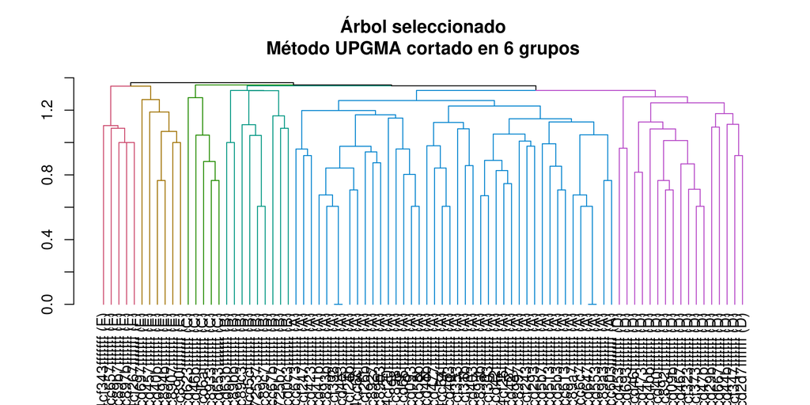

```r
# Convierte el hclust en dendrograma
dend <- as.dendrogram(grupos_seleccionados$arbol)

# Corta y colorea el dendrograma en k grupos
dend_colored <- color_branches(dend, k=grupos_seleccionados$k)

# Etiqueta los grupos
labels_colors <- labels_colors(dend_colored)
labels(dend_colored) <- paste0(labels(dend_colored), " (",
                               grupos_seleccionados$resultado[grupos_seleccionados$arbol$order],
                               ")")

# Grafica el dendrograma
# par(mar = c(3, 4, 4, 2) + 0.1) # Ajusta los márgenes
plot(
  dend_colored,
  main=paste(
    'Árbol seleccionado\nMétodo',
    grupos_seleccionados$metodo,
    'cortado en',
    grupos_seleccionados$k, 'grupos'),
  xlab = 'Sitios (grupo de pertenencia)')
```

## 2.5 Grupos (clústers), variables ambientales

Apliquemos el análisis de agrupamiento a la matriz ambiental. La idea central en este punto es que, si la matriz ambiental presenta patrones parecidos a los de la matriz de comunidad, significa que el agrupamiento utilizado hace sentido entre ambos conjuntos de datos (comunidad y hábitat) de forma consistente. Si ambos conjuntos de datos son consistentes, significa que existe algún grado de asociación, aunque sea sólo una mera asociación estadística. Por extensión, el hecho de que ambas matrices presenten patrones parecidos, significa que una podría tener poder explicativo sobre la otra (y viceversea), es decir, que las variables ambientales podrían ayudar a explicar la distribución de las especies de la familia elegida.

Agruparé los sitios de muestreo de la matriz ambiental según los grupos previamente definidos.

```r
env_grupos <- env %>%
    rownames_to_column('sitios_de_muestreo') %>%
    mutate(grupos = as.factor(grupos_seleccionados$resultado)) %>%
    pivot_longer(-c(grupos, sitios_de_muestreo), names_to = "variable", values_to = "valor")
```

Evaluar efectos entre los grupos (“diferencias significativas”). Se utilizan las pruebas estadísticas ANOVA (evalúa homongeneidad de medias) y Kruskal-Wallis (evalúa homogeneidad de medianas). Las tablas están ordenadas en orden ascendente por la columna `p_valor_a`, que son los p-valores de la prueba ANOVA.

```r
env_grupos_ak <- env_grupos %>%
  group_by(variable) %>%
  summarise(
    p_valor_a = tryCatch(oneway.test(valor ~ grupos)$p.value, error = function(e) NA),
    p_valor_k = tryCatch(kruskal.test(valor ~ grupos)$p.value, error = function(e) NA)
    ) %>%
  arrange(p_valor_a)
# env_grupos_ak %>% estilo_kable(alinear = 'crr')
env_grupos_ak %>%
  datatable(options = list(pageLength = 140, autoWidth = FALSE),
            filter = 'top',) %>%
  formatSignif(columns = "p_valor_a", digits = 1) %>%
  formatSignif(columns = "p_valor_k", digits = 1)
```

|  | variable | p_valor_a | p_valor_k |
| --- | --- | --- | --- |
| 1 | WCL bio07 Temperature annual range bio05-bio06 | 8.674627718618582e-06 | 0.0002215718004976354 |
| 2 | WCL bio13 Precipitation of wettest month | 2.191417602895231e-05 | 0.0001376171146604608 |
| 3 | WCL bio02 Mean diurnal range mean of monthly max temp - min temp | 0.0001069755654262335 | 2.103687034374592e-05 |
| 4 | GFC-LOSS year 2017 | 0.0001296199913556547 | 0.001224722305523937 |
| 5 | WCL bio03 Isothermality bio02 div/bio07 | 0.0001631152523264804 | 0.000198460812440969 |
| 6 | WCL bio12 Annual precipitation | 0.0001797497309182752 | 0.0002130509629628437 |
| 7 | GFC-PTC YEAR 2000 mean | 0.000335857947095984 | 0.0002102882502596115 |
| 8 | GHH mean_1km | 0.0005218759733612434 | 0.01155405578793003 |
| 9 | CH-BIO bio13 precipitation amount of the wettest month | 0.0005510433012038758 | 4.671167840913508e-05 |
| 10 | WCL bio16 Precipitation of wettest quarter | 0.0005613225296189219 | 0.002038016475939616 |

[output cut: 130 more lines]

Interesan especialmente, aquellas variables que presentan efecto entre los grupos. En concreto, aquellas en las que la prueba de Kruskal-Wallis resulta significativa, pues esta prueba es más robusta que la ANOVA en ausencia normalidad y homocedasticidad. Se puede filtrar el resultado de la tabla anterior para mostrar sólo aquellas variables en las que la prueba de Kruskal-Wallis resulta significativa (nota que en la tabla anterior también puedes filtrar de forma interactiva).

```r
env_grupos_ak %>%
  filter(p_valor_k < umbral_alfa) %>%
  datatable(options = list(pageLength = 140, autoWidth = FALSE),
            filter = 'top',) %>%
  formatSignif(columns = "p_valor_a", digits = 1) %>%
  formatSignif(columns = "p_valor_k", digits = 1)
```

|  | variable | p_valor_a | p_valor_k |
| --- | --- | --- | --- |
| 1 | WCL bio07 Temperature annual range bio05-bio06 | 8.674627718618582e-06 | 0.0002215718004976354 |
| 2 | WCL bio13 Precipitation of wettest month | 2.191417602895231e-05 | 0.0001376171146604608 |
| 3 | WCL bio02 Mean diurnal range mean of monthly max temp - min temp | 0.0001069755654262335 | 2.103687034374592e-05 |
| 4 | GFC-LOSS year 2017 | 0.0001296199913556547 | 0.001224722305523937 |
| 5 | WCL bio03 Isothermality bio02 div/bio07 | 0.0001631152523264804 | 0.000198460812440969 |
| 6 | WCL bio12 Annual precipitation | 0.0001797497309182752 | 0.0002130509629628437 |
| 7 | GFC-PTC YEAR 2000 mean | 0.000335857947095984 | 0.0002102882502596115 |
| 8 | GHH mean_1km | 0.0005218759733612434 | 0.01155405578793003 |
| 9 | CH-BIO bio13 precipitation amount of the wettest month | 0.0005510433012038758 | 4.671167840913508e-05 |
| 10 | WCL bio16 Precipitation of wettest quarter | 0.0005613225296189219 | 0.002038016475939616 |

[output cut: 83 more lines]

En el ejemplo analizado, nota que las variables que muestran efecto son bioclimáticas (CH-BIO, WCL), horas de insolación, distancia a carretera (¿sesgo de muestreo?), algunas variables de cobertura del suelo (ESA, CGL) y otras de topografía/geomorfología (G90).

Explora tus resultados también gráficamente, usando un panel de diagramas de cajas.

[figure not shown]

```r
env_grupos_p <- env_grupos %>%
  group_by(variable) %>%
  ggplot() + aes(x = grupos, y = valor, group = grupos, fill = grupos) +
  geom_boxplot(lwd = 0.2) +
  scale_fill_brewer(palette = 'Set1') +
  theme_bw() +
  theme(legend.position="none") +
  facet_wrap(
    ~ variable,
    scales = 'free_y',
    ncol = 8,
    labeller = labeller(
      variable = function(x)
        str_trunc(x, width = 45, ellipsis = '...')))
env_grupos_p
```

El gráfico anterior, seguramente será ilegible en la pestaña de gráficos de RStudio, pero puedes hacerlo legible exportándolo como JPEG (los nombres de cada *facet* corresponde a cada una de las 140 variables, pero están truncados a partir del caracter 45; para ver los nombres completos, usa `unique(env_grupos$variable)` en la consola de R; el significado de cada variable se encuentra en el [repo fuente](https://geofis.github.io/zonal-statistics/README.html)):

```r
jpeg('env_grupos_p.jpg', width = 3000, height = 4000, res = 100)
print(env_grupos_p)
graphics.off()
```

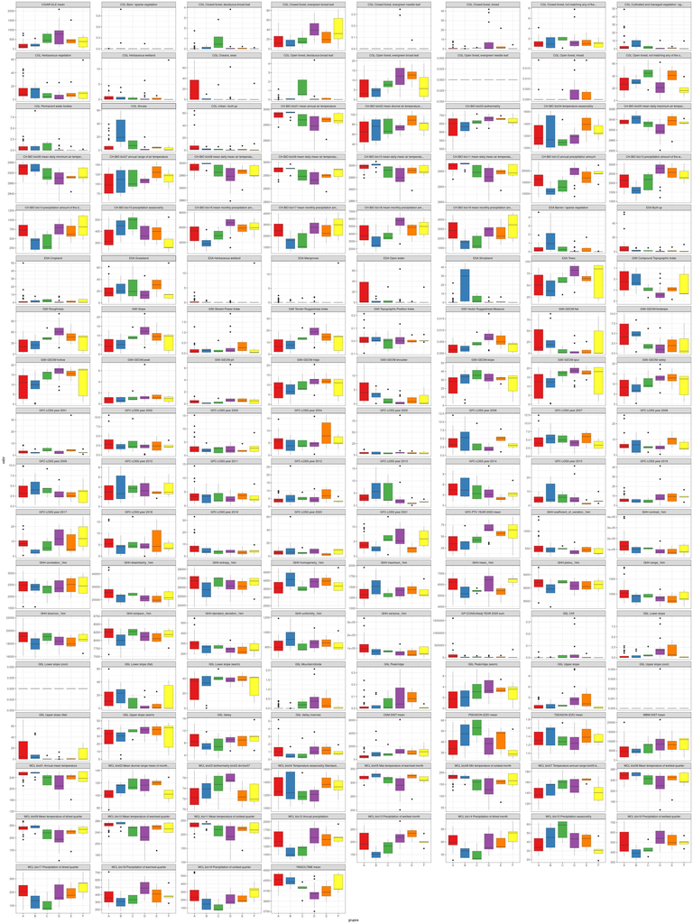

(#fig:env_grupos_p)Variables ambientales de República Dominicana según agrupamiento de sitios en función de su riqueza de especies de Acanthaceae

Es útil representar, cartográficamente, los grupos de hexágonos en función de su riqueza de especies de la familia eleida, en este caso, Acanthaceae. Este código lo muestra.

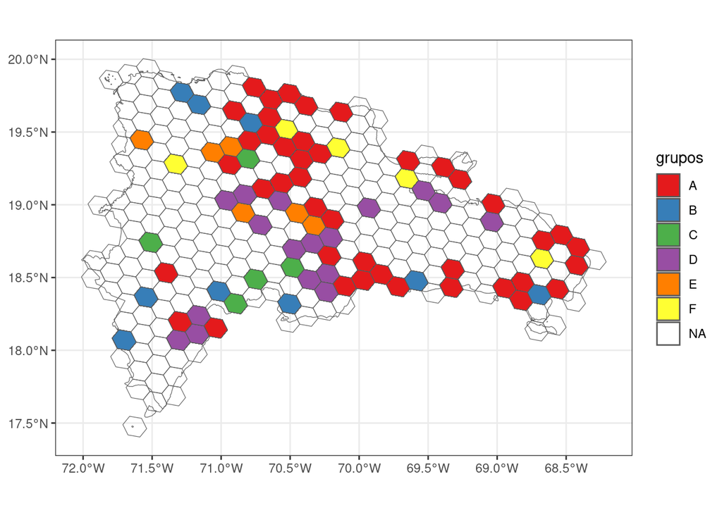

```r
# Mapa
todos_los_objetos$aoi_reg_hex_inter_g$layers[[2]]$data %>% left_join(
  env_grupos %>%
    select(h3_address = sitios_de_muestreo, grupos) %>%
    as.data.frame()) %>%
  ggplot() +
  aes(fill = grupos) +
  geom_sf(data = todos_los_objetos$aoi_reg_hex_inter_g$data, fill = NA) +
  geom_sf() +
  scale_fill_brewer(palette = 'Set1') +
  theme_bw()
```

El objetivo de adjuntarle, a la matriz ambiental, el vector de agrupamiento generado a partir de datos de comunidad, consiste en caracterizar ambientalmente los hábitats de los subgrupos diferenciados según su composición. Observa los resultados de las pruebas estadísticas, de los diagramas de caja, y explora tus resultados:

## 2.6 Especies con preferencia/fidelidad con grupos (clústers)

Análisis de preferencia/fidelidad de especies con grupos (clusters), mediante el coeficiente de correlación biserial puntual (*phi*).

```r
set.seed(9999)
phi <- multipatt(
  mc,
  grupos_seleccionados$resultado,
  func = "r.g",
  max.order = 1,
  control = how(nperm = 999))
summary(phi)
```

```
 Multilevel pattern analysis
 ---------------------------

 Association function: r.g
 Significance level (alpha): 0.05

 Total number of species: 42
 Selected number of species: 12
 Number of species associated to 1 group: 12
 Number of species associated to 2 groups: 0
 Number of species associated to 3 groups: 0
 Number of species associated to 4 groups: 0
 Number of species associated to 5 groups: 0

 List of species associated to each combination:

 Group A  #sps.  2
                                                 stat p.value
Asystasia gangetica (L.) T.Anderson             0.443   0.028 *
Thunbergia grandiflora (Roxb. ex Rottler) Roxb. 0.437   0.022 *

 Group B  #sps.  3
                              stat p.value
Barleria lupulina Lindl.     0.537   0.012 *
Oplonia spinosa (Jacq.) Raf. 0.522   0.013 *
Ruellia ciliatiflora Hook.   0.518   0.024 *

 Group C  #sps.  2
                                     stat p.value
Dyschoriste diffusa (Nees) Urb.     0.737   0.001 ***
Ruellia domingensis Spreng. ex Nees 0.692   0.001 ***

 Group D  #sps.  2
                                     stat p.value
Odontonema cuspidatum (Nees) Kuntze 0.662   0.001 ***
Ruellia coccinea (L.) Vahl          0.509   0.015 *

 Group E  #sps.  2
                                 stat p.value
Stenandrium tuberosum (L.) Urb. 0.867   0.001 ***
Ruellia blechum L.              0.495   0.015 *

 Group F  #sps.  1
                                                    stat p.value
Lepidagathis alopecuroidea (Vahl) R.Br. ex Griseb. 0.883   0.001 ***
---
Signif. codes:  0 '***' 0.001 '**' 0.01 '*' 0.05 '.' 0.1 ' ' 1
```

Tabla de especies que presentaron asociación con grupos por medio de *phi*, usando umbral de significancia (`umbral_alfa`).

```r
tabla_phi_sign <- phi$sign
tabla_phi_sign_alfa <- tabla_phi_sign[phi$sign$p.value < umbral_alfa, ]
data.frame(
  `Nombre de especie` = rownames(tabla_phi_sign_alfa),
  `P-valor` = tabla_phi_sign_alfa$p.value,
  `Grupo de asociación` = gsub('s\\.', '', names(tabla_phi_sign_alfa)[tabla_phi_sign_alfa$index]),
  check.names = F) %>%
  arrange(`Nombre de especie`) %>%
  estilo_kable(alinear = 'crr')
```

Table 2.2:

| Nombre de especie | P-valor | Grupo de asociación |
| --- | --- | --- |
| Asystasia gangetica (L.) T.Anderson | 0.03 | A |
| Barleria lupulina Lindl. | 0.01 | B |
| Dyschoriste diffusa (Nees) Urb. | 0.00 | C |
| Lepidagathis alopecuroidea (Vahl) R.Br. ex Griseb. | 0.00 | F |
| Odontonema cuspidatum (Nees) Kuntze | 0.00 | D |
| Oplonia spinosa (Jacq.) Raf. | 0.01 | B |
| Ruellia blechum L. | 0.01 | E |
| Ruellia ciliatiflora Hook. | 0.02 | B |
| Ruellia coccinea (L.) Vahl | 0.01 | D |
| Ruellia domingensis Spreng. ex Nees | 0.00 | C |
| Stenandrium tuberosum (L.) Urb. | 0.00 | E |
| Thunbergia grandiflora (Roxb. ex Rottler) Roxb. | 0.02 | A |

# 3 Técnicas de ordenación

Me basaré en los scripts que comienzan por `to_` de este [repo](https://github.com/biogeografia-master/scripts-de-analisis-BCI), los cuales explico en los vídeos de “Técnicas de ordenación” de la lista de reproducción [“Ecología Numérica con R” de mi canal](https://www.youtube.com/playlist?list=PLDcT2n8UzsCRDqjqSeqHI1wsiNOqpYmsJ).

## 3.1 Ordenación no restringida

### 3.1.1 PCA aplicado a datos de comunidad transformados

```r
pca_mc_t <- rda(mc_t)
summary(pca_mc_t)
```

```
Call:
rda(X = mc_t)

Partitioning of variance:
              Inertia Proportion
Total          0.8562          1
Unconstrained  0.8562          1

Eigenvalues, and their contribution to the variance

Importance of components:
                          PC1     PC2     PC3     PC4     PC5     PC6     PC7
Eigenvalue            0.09553 0.07476 0.06472 0.05891 0.05044 0.04599 0.04209
Proportion Explained  0.11158 0.08731 0.07559 0.06880 0.05891 0.05372 0.04916
Cumulative Proportion 0.11158 0.19889 0.27448 0.34328 0.40220 0.45592 0.50508
                          PC8     PC9    PC10    PC11    PC12    PC13    PC14
Eigenvalue            0.03978 0.03632 0.02881 0.02776 0.02630 0.02383 0.02212
Proportion Explained  0.04647 0.04242 0.03365 0.03242 0.03072 0.02784 0.02584
Cumulative Proportion 0.55155 0.59396 0.62761 0.66004 0.69076 0.71860 0.74444
                         PC15    PC16    PC17    PC18    PC19    PC20    PC21
Eigenvalue            0.02057 0.01937 0.01820 0.01711 0.01467 0.01381 0.01330
Proportion Explained  0.02402 0.02263 0.02126 0.01999 0.01713 0.01612 0.01553
Cumulative Proportion 0.76846 0.79109 0.81234 0.83233 0.84947 0.86559 0.88112
                         PC22    PC23     PC24     PC25     PC26     PC27
Eigenvalue            0.01105 0.01039 0.009678 0.009009 0.008378 0.007171
Proportion Explained  0.01290 0.01213 0.011304 0.010522 0.009785 0.008375
Cumulative Proportion 0.89402 0.90615 0.917458 0.927980 0.937765 0.946140
                          PC28    PC29     PC30     PC31     PC32     PC33
Eigenvalue            0.006401 0.00601 0.005862 0.004552 0.004369 0.003402
Proportion Explained  0.007477 0.00702 0.006847 0.005317 0.005103 0.003973
Cumulative Proportion 0.953616 0.96064 0.967483 0.972799 0.977902 0.981875
                          PC34     PC35     PC36     PC37     PC38     PC39
Eigenvalue            0.003131 0.002803 0.002288 0.001842 0.001716 0.001335
Proportion Explained  0.003657 0.003273 0.002673 0.002152 0.002004 0.001559
Cumulative Proportion 0.985531 0.988805 0.991477 0.993629 0.995633 0.997193
                          PC40      PC41      PC42
Eigenvalue            0.001063 0.0008000 0.0005411
Proportion Explained  0.001241 0.0009344 0.0006320
Cumulative Proportion 0.998434 0.9993680 1.0000000
```

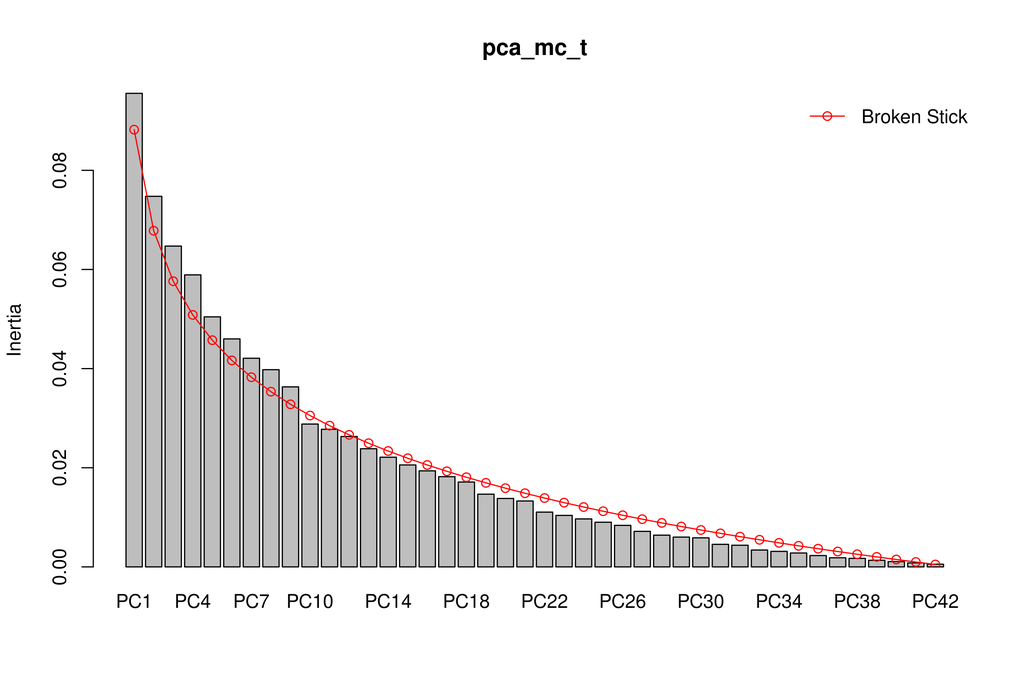

```r
screeplot(
  pca_mc_t,
  bstick = TRUE,
  npcs = length(pca_mc_t$CA$eig)
)
```

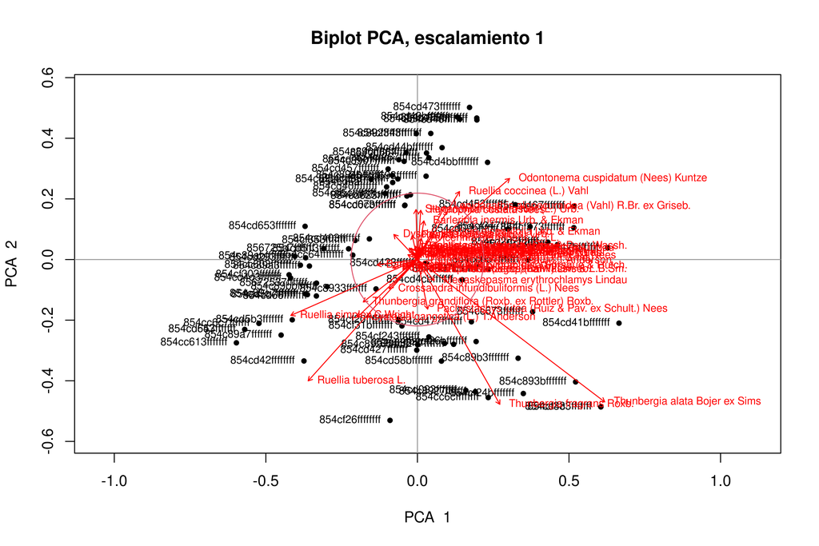

```r
# Biplot
cleanplot.pca(pca_mc_t, scaling = 1, mar.percent = 0.06, cex.char1 = 0.7)
```

### 3.1.2 Análisis de correspondencia (CA)

```r
# Realizar el CA
mc_ca <- cca(mc)
```

Resumen de análisis de correspondencia.

```r
summary(mc_ca)
```

```
Call:
cca(X = mc)

Partitioning of scaled Chi-square:
              Inertia Proportion
Total           10.18          1
Unconstrained   10.18          1

Eigenvalues, and their contribution to the scaled Chi-square

Importance of components:
                          CA1     CA2     CA3     CA4     CA5     CA6     CA7
Eigenvalue            0.64349 0.61074 0.56210 0.54988 0.53924 0.47728 0.45560
Proportion Explained  0.06322 0.06001 0.05523 0.05403 0.05298 0.04689 0.04476
Cumulative Proportion 0.06322 0.12323 0.17846 0.23248 0.28546 0.33236 0.37712
                          CA8     CA9    CA10    CA11    CA12    CA13   CA14
Eigenvalue            0.44412 0.41799 0.38764 0.37569 0.36284 0.34840 0.3267
Proportion Explained  0.04364 0.04107 0.03809 0.03691 0.03565 0.03423 0.0321
Cumulative Proportion 0.42076 0.46183 0.49991 0.53682 0.57247 0.60670 0.6388
                        CA15    CA16    CA17    CA18    CA19    CA20    CA21
Eigenvalue            0.2972 0.27004 0.24871 0.24246 0.23396 0.22429 0.20537
Proportion Explained  0.0292 0.02653 0.02444 0.02382 0.02299 0.02204 0.02018
Cumulative Proportion 0.6680 0.69453 0.71897 0.74279 0.76578 0.78782 0.80799
                         CA22    CA23    CA24    CA25    CA26    CA27   CA28
Eigenvalue            0.19379 0.17111 0.16638 0.15741 0.14890 0.13657 0.1313
Proportion Explained  0.01904 0.01681 0.01635 0.01547 0.01463 0.01342 0.0129
Cumulative Proportion 0.82703 0.84385 0.86019 0.87566 0.89029 0.90371 0.9166
                         CA29   CA30    CA31    CA32     CA33     CA34     CA35
Eigenvalue            0.11887 0.1079 0.10553 0.07990 0.075909 0.067576 0.061321
Proportion Explained  0.01168 0.0106 0.01037 0.00785 0.007458 0.006639 0.006025
Cumulative Proportion 0.92829 0.9389 0.94926 0.95711 0.964566 0.971205 0.977230
                          CA36     CA37     CA38     CA39    CA40     CA41
Eigenvalue            0.053644 0.050735 0.040879 0.032686 0.02748 0.026331
Proportion Explained  0.005271 0.004985 0.004016 0.003211 0.00270 0.002587
Cumulative Proportion 0.982501 0.987485 0.991502 0.994713 0.99741 1.000000
```

Gráfico de sedimentación o *screeplot*.

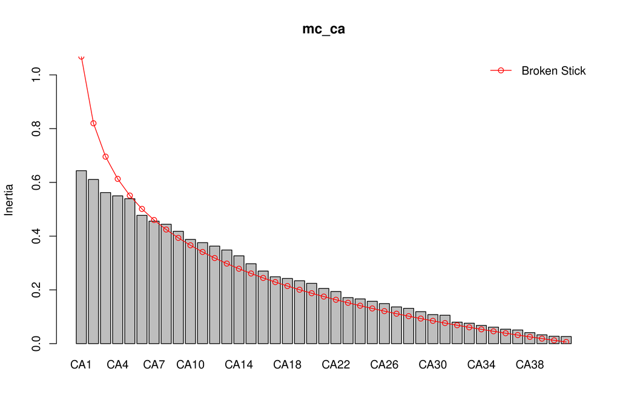

```r
# Screeplot
screeplot(mc_ca, bstick = TRUE, npcs = length(mc_ca$CA$eig))
```

Representación del *biplot*.

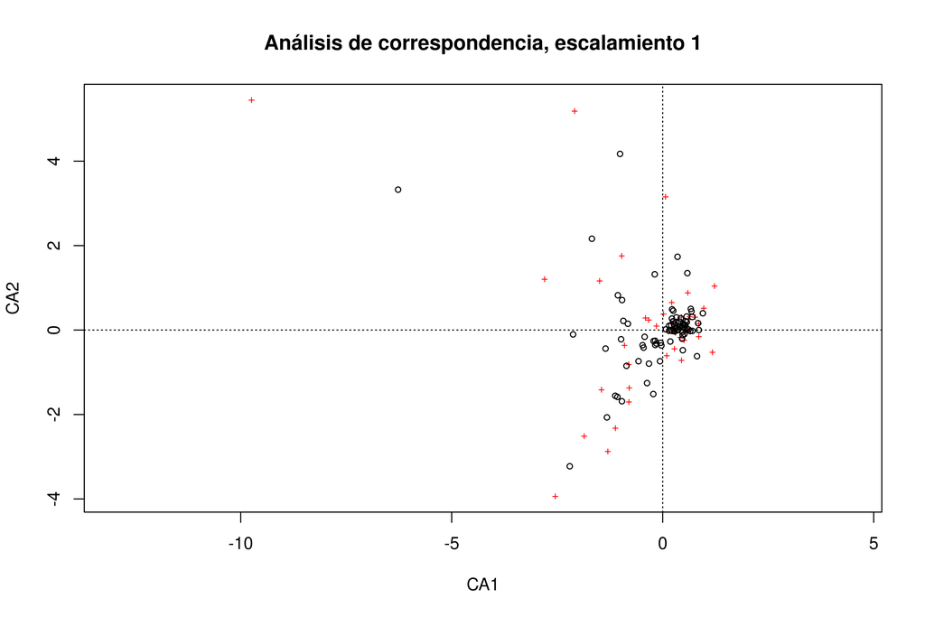

```r
# Biplot
plot(mc_ca,
     scaling = 1,
     main = "Análisis de correspondencia, escalamiento 1"
)
```

## 3.2 Ordenación restringida con modelización

A continuación, el análisis de ordenación propiamente. La parte más importante es el entrenamiento: la función `train` del paquete `caret`, contenida en la función `my_train`, simplifica la selección de variables. Lo más importante: prueba con todas las variables primero, observa las variables que recomienda el modelo final (`print_my_train(mod)`) y ensaya varias combinaciones de subconjuntos de variables.

```r
mc_t_ren <- mc_t %>%
  rename_all(~ paste('ESPECIE', .x))
env_spp <- env %>% bind_cols(mc_t_ren)
spp <- paste0('`', grep('^ESPECIE', colnames(env_spp), value = T), '`', collapse = ' + ')
my_formula <- as.formula(paste(spp, '~ .'))
set.seed(1); mod <- my_train(
  formula = my_formula,
  # preproceso = 'scale',
  data = env_spp,
  num_variables = 3:4)
```

```
Reordering variables and trying again:
Reordering variables and trying again:
Reordering variables and trying again:
Reordering variables and trying again:
```

```r
print_my_train(mod)
```

```
$resumen_variables
Subset selection object
140 Variables  (and intercept)
                                                                        Forced in
`ESA Trees`                                                                 FALSE
`ESA Shrubland`                                                             FALSE
`ESA Grassland`                                                             FALSE
`ESA Cropland`                                                              FALSE
`ESA Built-up`                                                              FALSE
`ESA Barren / sparse vegetation`                                            FALSE
`ESA Open water`                                                            FALSE
`ESA Herbaceous wetland`                                                    FALSE
`CGL Closed forest, evergreen needle leaf`                                  FALSE
`CGL Closed forest, evergreen broad leaf`                                   FALSE
`CGL Closed forest, deciduous broad leaf`                                   FALSE
`CGL Closed forest, mixed`                                                  FALSE
`CGL Closed forest, not matching any of the other definitions`              FALSE
`CGL Open forest, evergreen broad leaf`                                     FALSE
`CGL Open forest, deciduous broad leaf`                                     FALSE
`CGL Open forest, mixed`                                                    FALSE
`CGL Open forest, not matching any of the other definitions`                FALSE
`CGL Shrubs`                                                                FALSE
`CGL Oceans, seas`                                                          FALSE
`CGL Herbaceous vegetation`                                                 FALSE
`CGL Cultivated and managed vegetation / agriculture`                       FALSE
`CGL Urban / built up`                                                      FALSE
`CGL Bare / sparse vegetation`                                              FALSE
`CGL Permanent water bodies`                                                FALSE
`GSL Peak/ridge (warm)`                                                     FALSE
`GSL Peak/ridge`                                                            FALSE
`GSL Mountain/divide`                                                       FALSE
`GSL Cliff`                                                                 FALSE
`GSL Upper slope (warm)`                                                    FALSE
`GSL Upper slope`                                                           FALSE
`GSL Upper slope (cool)`                                                    FALSE
`GSL Upper slope (flat)`                                                    FALSE
`GSL Lower slope (warm)`                                                    FALSE
`GSL Lower slope`                                                           FALSE
`GSL Lower slope (flat)`                                                    FALSE
`GSL Valley`                                                                FALSE
```

[output cut: 631 more lines]

```
4  ( 1 ) " "               " "             " "
         `PSEASON-IZZO mean`
1  ( 1 ) " "
2  ( 1 ) " "
3  ( 1 ) " "
4  ( 1 ) " "

$resultados_nvmax
  nvmax      RMSE   Rsquared       MAE     RMSESD RsquaredSD      MAESD
1     3 0.5201003 0.06652765 0.4020472 0.04826205 0.04597350 0.05066464
2     4 0.7640892 0.09736757 0.5103710 0.36793013 0.08163982 0.12300167

$mejor_ajuste
  nvmax
1     3
```

```r
(covar <- grep(
  pattern = '\\(Intercept\\)',
  x = names(coef(mod$finalModel,unlist(mod$bestTune))),
  invert = T, value = T))
```

```
[1] "`CGL Permanent water bodies`"
[2] "`CH-BIO bio04 temperature seasonality`"
[3] "`CH-BIO bio06 mean daily minimum air temperature of the coldest month`"
```

```r
rda_mc_t <- rda(mc_t_ren %>% rename_all(~ gsub('^ESPECIE ', '', .)) ~ .,
                    env %>% select_at(all_of(gsub('\\`', '', covar))), scale = T)
```

A continuación, el resumen del análisis de redundancia.

```r
summary(rda_mc_t)
```

```
Call:
rda(formula = mc_t_ren %>% rename_all(~gsub("^ESPECIE ", "",      .)) ~ `CGL Permanent water bodies` + `CH-BIO bio04 temperature seasonality` +      `CH-BIO bio06 mean daily minimum air temperature of the coldest month`,      data = env %>% select_at(all_of(gsub("\\`", "", covar))),      scale = T)

Partitioning of correlations:
              Inertia Proportion
Total          42.000    1.00000
Constrained     2.753    0.06554
Unconstrained  39.247    0.93446

Eigenvalues, and their contribution to the correlations

Importance of components:
                        RDA1    RDA2     RDA3     PC1     PC2     PC3     PC4
Eigenvalue            1.5581 0.85299 0.341717 2.35744 2.16778 2.06989 1.95270
Proportion Explained  0.0371 0.02031 0.008136 0.05613 0.05161 0.04928 0.04649
Cumulative Proportion 0.0371 0.05741 0.065543 0.12167 0.17329 0.22257 0.26906
                          PC5     PC6    PC7     PC8     PC9    PC10    PC11
Eigenvalue            1.85968 1.78727 1.7513 1.62608 1.55278 1.47688 1.37890
Proportion Explained  0.04428 0.04255 0.0417 0.03872 0.03697 0.03516 0.03283
Cumulative Proportion 0.31334 0.35589 0.3976 0.43631 0.47328 0.50844 0.54128
                         PC12    PC13    PC14    PC15    PC16    PC17    PC18
Eigenvalue            1.27236 1.20593 1.16274 1.14201 1.09532 1.04712 1.01592
Proportion Explained  0.03029 0.02871 0.02768 0.02719 0.02608 0.02493 0.02419
Cumulative Proportion 0.57157 0.60028 0.62797 0.65516 0.68124 0.70617 0.73036
                        PC19    PC20    PC21    PC22    PC23    PC24    PC25
Eigenvalue            0.9784 0.94373 0.89987 0.81212 0.79160 0.72610 0.67503
Proportion Explained  0.0233 0.02247 0.02143 0.01934 0.01885 0.01729 0.01607
Cumulative Proportion 0.7537 0.77612 0.79755 0.81688 0.83573 0.85302 0.86909
                         PC26    PC27    PC28   PC29    PC30    PC31     PC32
Eigenvalue            0.61356 0.56025 0.54623 0.5167 0.44075 0.43207 0.385796
Proportion Explained  0.01461 0.01334 0.01301 0.0123 0.01049 0.01029 0.009186
Cumulative Proportion 0.88370 0.89704 0.91004 0.9223 0.93284 0.94313 0.952313
                          PC33     PC34     PC35     PC36     PC37     PC38
Eigenvalue            0.332738 0.313896 0.305979 0.242806 0.205956 0.163543
Proportion Explained  0.007922 0.007474 0.007285 0.005781 0.004904 0.003894
Cumulative Proportion 0.960236 0.967709 0.974995 0.980776 0.985679 0.989573
                          PC39     PC40     PC41     PC42
Eigenvalue            0.151004 0.116041 0.104208 0.066665
Proportion Explained  0.003595 0.002763 0.002481 0.001587
Cumulative Proportion 0.993169 0.995932 0.998413 1.000000

Accumulated constrained eigenvalues
Importance of components:
                       RDA1   RDA2   RDA3
Eigenvalue            1.558 0.8530 0.3417
Proportion Explained  0.566 0.3099 0.1241
Cumulative Proportion 0.566 0.8759 1.0000
```

La varianza ajustada explicada por el modelo.

```r
RsquareAdj(rda_mc_t)$adj.r.squared
```

```
[1] 0.0305013
```

Y el factor de inflación de la varianza.

```r
vif.cca(rda_mc_t)
```

```
                                          `CGL Permanent water bodies`
                                                              1.159839
                                `CH-BIO bio04 temperature seasonality`
                                                              1.164650
`CH-BIO bio06 mean daily minimum air temperature of the coldest month`
                                                              1.136625
```

Represento el gráfico *triplot*.

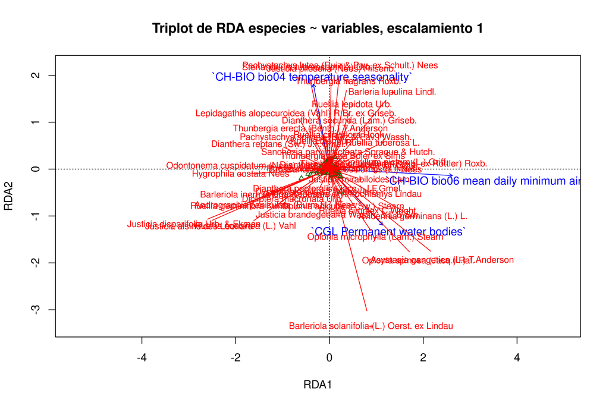

```r
# Triplot
escalado <- 1
plot(rda_mc_t,
     scaling = escalado,
     display = c("sp", "lc", "cn"),
     main = paste("Triplot de RDA especies ~ variables, escalamiento", escalado)
)
rda_mc_t_sc1 <- scores(rda_mc_t,
         choices = 1:2,
         scaling = escalado,
         display = "sp"
  )
text(rda_mc_t, "species", col="red", cex=0.8, scaling=escalado)
arrows(0, 0,
       rda_mc_t_sc1[, 1] * 0.9,
       rda_mc_t_sc1[, 2] * 0.9,
       length = 0,
       lty = 1,
       col = "red"
)
```

El gráfico, casi seguramente, es ilegible. Recuerda que puedes exportarlo como JPEG usando cualquiera de los casos de uso anteriores.

# 4 Análisis de diversidad + análisis de agrupamiento abreviado

Me basaré en los scripts que comienzan por `di_` de este [repo](https://github.com/biogeografia-master/scripts-de-analisis-BCI), los cuales explico en los vídeos de “Análisis de diversidad” (vídeos 19 y 20) de la lista de reproducción [“Ecología Numérica con R” de mi canal](https://www.youtube.com/playlist?list=PLDcT2n8UzsCRDqjqSeqHI1wsiNOqpYmsJ). Dichos vídeos tienen aplicaciones ligeramente diferentes, pues los datos fuente usados en ellos son de abundancia, mientras que los tuyos son de presencia/ausencia.

## 4.1 Calcular riqueza (e índices)

La principal desventaja de trabajar con registros de presencia, es que la mayoría de los índices de diversidad alpha fueron diseñados originalmente para calcularse a partir de datos de abundancia. Sin embargo, la riqueza de especies, que es el número $q=0$ de Hill ($=N_0$ en las columnas que produce la función `alpha_div`) es un buen proxy sobre la diversidad, y nos ayudará a comparar sitios.

Además de la columna `N0` del objeto que generaré en el bloque siguiente, verás que la función `alpha_div` genera otras columnas; son índices pensados para datos de abundancia, que en este caso no usaremos, pero los muestro para que tengas una visión completa del análisis de diversidad con índices que podría serte de utilidad en el futuro.

Por otra parte, afortunadamente, los métodos de estimación de riqueza de Chao, y los de diversidad beta (al final de esta sección), aprovechan sustancialmente los registros de presencia/ausencia para realizar estimaciones consistentes y fiables.

> Una nota adicional. En el análisis de diversidad, es útil (no imprescindible) disponer de un análisis clúster (agrupamiento) básico. Este te servirá para comparar la riqueza observada y la esperada entre hábitats. Por esta razón, combinamos análisis de diversidad con agrupamiento. Sin embargo, si el análisis de agrupamiento generó grupos de dos o menos elementos, dicha comparación no será realizable.

```r
indices <- alpha_div(mc) %>%
  mutate(sitio = rownames(.)) %>%
  relocate(sitio, .before = everything())
```

El objeto `mc` es la matriz de comunidad de presecia/ausencia. La función `alpha_div` es un “envoltorio” generado por mí para calcular múltiples índices de diversidad y estimaciones, basada en las funciones de los paquetes `SpadeR` y `iNEXT`. Si usásemos datos de abundancia, los índices que calcula la función “alpha_div” serían útiles, pero con registros de presencia/ausencia, como es nuestro caso, sólo la columna N0 (riqueza) nos aportará algún resultado con sentido.

```r
indices %>%
  select(sitio, N0, H, Hb2) %>%
  kable(booktabs=T) %>%
  kable_styling(latex_options = c("HOLD_position", "scale_down")) %>%
  gsub(' NA |NaN ', '', .) #Lista de especies
```

|  | sitio | N0 | H | Hb2 |
| --- | --- | --- | --- | --- |
| 854cd4cbfffffff | 854cd4cbfffffff | 11 | 2.3978953 | 3.459432 |
| 854c8927fffffff | 854c8927fffffff | 6 | 1.7917595 | 2.584963 |
| 85672537fffffff | 85672537fffffff | 3 | 1.0986123 | 1.584963 |
| 854c89abfffffff | 854c89abfffffff | 5 | 1.6094379 | 2.321928 |
| 854c8933fffffff | 854c8933fffffff | 4 | 1.3862944 | 2.000000 |
| 854c8997fffffff | 854c8997fffffff | 13 | 2.5649494 | 3.700440 |
| 854cf247fffffff | 854cf247fffffff | 2 | 0.6931472 | 1.000000 |
| 854cd29bfffffff | 854cd29bfffffff | 5 | 1.6094379 | 2.321928 |
| 854cd477fffffff | 854cd477fffffff | 4 | 1.3862944 | 2.000000 |
| 854cd46bfffffff | 854cd46bfffffff | 2 | 0.6931472 | 1.000000 |
| 854c89b3fffffff | 854c89b3fffffff | 7 | 1.9459101 | 2.807355 |
| 854cd40bfffffff | 854cd40bfffffff | 4 | 1.3862944 | 2.000000 |
| 854cf373fffffff | 854cf373fffffff | 3 | 1.0986123 | 1.584963 |
| 854cd423fffffff | 854cd423fffffff | 6 | 1.7917595 | 2.584963 |
| 854cc6c7fffffff | 854cc6c7fffffff | 3 | 1.0986123 | 1.584963 |
| 854c892ffffffff | 854c892ffffffff | 4 | 1.3862944 | 2.000000 |
| 854cd63bfffffff | 854cd63bfffffff | 2 | 0.6931472 | 1.000000 |
| 854cd457fffffff | 854cd457fffffff | 5 | 1.6094379 | 2.321928 |
| 856725b7fffffff | 856725b7fffffff | 6 | 1.7917595 | 2.584963 |
| 854cf26ffffffff | 854cf26ffffffff | 6 | 1.7917595 | 2.584963 |
| 854c89a3fffffff | 854c89a3fffffff | 6 | 1.7917595 | 2.584963 |
| 854cd647fffffff | 854cd647fffffff | 2 | 0.6931472 | 1.000000 |
| 854cd453fffffff | 854cd453fffffff | 7 | 1.9459101 | 2.807355 |
| 854c89c7fffffff | 854c89c7fffffff | 2 | 0.6931472 | 1.000000 |
| 854c89c3fffffff | 854c89c3fffffff | 3 | 1.0986123 | 1.584963 |
| 854c8907fffffff | 854c8907fffffff | 2 | 0.6931472 | 1.000000 |
| 854cf347fffffff | 854cf347fffffff | 4 | 1.3862944 | 2.000000 |
| 854cd4bbfffffff | 854cd4bbfffffff | 2 | 0.6931472 | 1.000000 |
| 854cf24bfffffff | 854cf24bfffffff | 4 | 1.3862944 | 2.000000 |
| 854cd0c3fffffff | 854cd0c3fffffff | 4 | 1.3862944 | 2.000000 |

[output cut: 54 more lines]

Los sitios ordenados en función de su riqueza:

```r
indices %>%
  select(sitio, N0, H, Hb2) %>%
  arrange(desc(N0)) %>%
  kable(booktabs=T) %>%
  kable_styling(latex_options = c("HOLD_position", "scale_down")) %>%
  gsub(' NA |NaN ', '', .) #Lista de especies
```

|  | sitio | N0 | H | Hb2 |
| --- | --- | --- | --- | --- |
| 854c8997fffffff | 854c8997fffffff | 13 | 2.5649494 | 3.700440 |
| 854cd4cbfffffff | 854cd4cbfffffff | 11 | 2.3978953 | 3.459432 |
| 854cf243fffffff | 854cf243fffffff | 11 | 2.3978953 | 3.459432 |
| 854cd42ffffffff | 854cd42ffffffff | 10 | 2.3025851 | 3.321928 |
| 854cd427fffffff | 854cd427fffffff | 8 | 2.0794415 | 3.000000 |
| 854c898ffffffff | 854c898ffffffff | 8 | 2.0794415 | 3.000000 |
| 854c89b3fffffff | 854c89b3fffffff | 7 | 1.9459101 | 2.807355 |
| 854cd453fffffff | 854cd453fffffff | 7 | 1.9459101 | 2.807355 |
| 854cd5b7fffffff | 854cd5b7fffffff | 7 | 1.9459101 | 2.807355 |
| 854c8927fffffff | 854c8927fffffff | 6 | 1.7917595 | 2.584963 |
| 854cd423fffffff | 854cd423fffffff | 6 | 1.7917595 | 2.584963 |
| 856725b7fffffff | 856725b7fffffff | 6 | 1.7917595 | 2.584963 |
| 854cf26ffffffff | 854cf26ffffffff | 6 | 1.7917595 | 2.584963 |
| 854c89a3fffffff | 854c89a3fffffff | 6 | 1.7917595 | 2.584963 |
| 854c89abfffffff | 854c89abfffffff | 5 | 1.6094379 | 2.321928 |
| 854cd29bfffffff | 854cd29bfffffff | 5 | 1.6094379 | 2.321928 |
| 854cd457fffffff | 854cd457fffffff | 5 | 1.6094379 | 2.321928 |
| 854cf31bfffffff | 854cf31bfffffff | 5 | 1.6094379 | 2.321928 |
| 854cd667fffffff | 854cd667fffffff | 5 | 1.6094379 | 2.321928 |
| 854c8933fffffff | 854c8933fffffff | 4 | 1.3862944 | 2.000000 |
| 854cd477fffffff | 854cd477fffffff | 4 | 1.3862944 | 2.000000 |
| 854cd40bfffffff | 854cd40bfffffff | 4 | 1.3862944 | 2.000000 |
| 854c892ffffffff | 854c892ffffffff | 4 | 1.3862944 | 2.000000 |
| 854cf347fffffff | 854cf347fffffff | 4 | 1.3862944 | 2.000000 |
| 854cf24bfffffff | 854cf24bfffffff | 4 | 1.3862944 | 2.000000 |
| 854cd0c3fffffff | 854cd0c3fffffff | 4 | 1.3862944 | 2.000000 |
| 854cd5b3fffffff | 854cd5b3fffffff | 4 | 1.3862944 | 2.000000 |
| 854cf20ffffffff | 854cf20ffffffff | 4 | 1.3862944 | 2.000000 |
| 854cc6cffffffff | 854cc6cffffffff | 4 | 1.3862944 | 2.000000 |
| 854cc613fffffff | 854cc613fffffff | 4 | 1.3862944 | 2.000000 |

[output cut: 54 more lines]

Mapas representando la riqueza (N0) y los índices H y Hb2

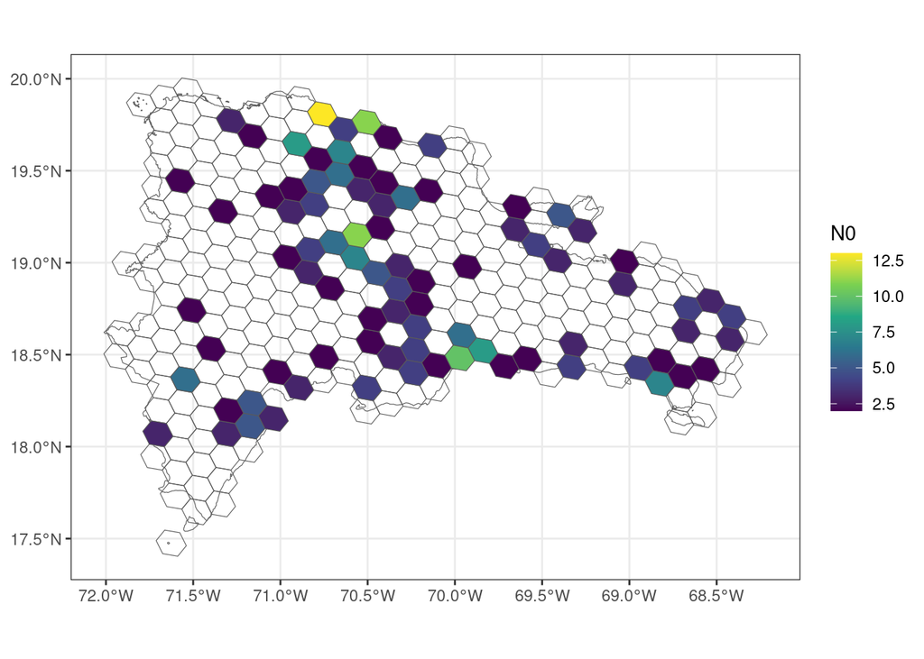

```r
# Mapa para N0
mapa_para_n0 <- todos_los_objetos$aoi_reg_hex_inter_g$layers[[2]]$data %>% left_join(
  indices %>%
    select(h3_address = sitio, N0) %>%
    as.data.frame()) %>%
  ggplot() +
  aes(fill = N0) +
  geom_sf(data = todos_los_objetos$aoi_reg_hex_inter_g$data, fill = NA) +
  geom_sf() +
  scale_fill_viridis_c(na.value = NA) +
  theme_bw()
mapa_para_n0
```

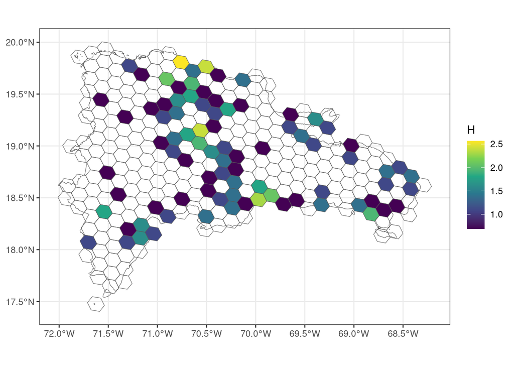

```r
# Mapa para H
mapa_para_h <- todos_los_objetos$aoi_reg_hex_inter_g$layers[[2]]$data %>% left_join(
  indices %>%
    select(h3_address = sitio, H) %>%
    as.data.frame()) %>%
  ggplot() +
  aes(fill = H) +
  geom_sf(data = todos_los_objetos$aoi_reg_hex_inter_g$data, fill = NA) +
  geom_sf() +
  scale_fill_viridis_c(na.value = NA) +
  theme_bw()
mapa_para_h
```

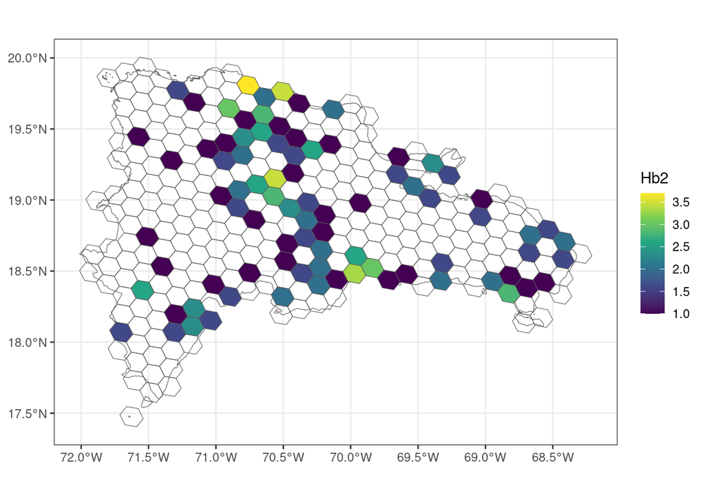

```r
# Mapa para Hb2
mapa_para_hb2 <- todos_los_objetos$aoi_reg_hex_inter_g$layers[[2]]$data %>% left_join(
  indices %>%
    select(h3_address = sitio, Hb2) %>%
    as.data.frame()) %>%
  ggplot() +
  aes(fill = Hb2) +
  geom_sf(data = todos_los_objetos$aoi_reg_hex_inter_g$data, fill = NA) +
  geom_sf() +
  scale_fill_viridis_c(na.value = NA) +
  theme_bw()
mapa_para_hb2
```

## 4.2 Evaluar correlación entre riqueza y variables ambientales mediante matriz de correlación.

En el bloque siguiente, represento gráficamente la correlación entre la riqueza y las variables ambientales mediante un panel de gráficos, que suele llamarse también “matriz de correlación”, expresada gráficamente. Si usases índices de diversidad, como el de Shannon o los números de Hill, también deberías incluirlos en el gráfico; nota que en este ejemplo, sólo uso la riqueza (la función `select(N0)` se encarga de conservar sólo la riqueza). Esto es lo que debes saber sobre el panel:

- Presta atención a la primera columna y la primera fila de la matriz, que muestra cómo se correlaciona `N0` con las variables ambientales que elijas.
- La diagonal contiene gráficos de línea que muestra la densidad de la variable en cuestión.
- Los gráficos del “triángulo superior”, y que contienen el patrón `Corr: ####`, muestran el valor del coeficiente de correlación de Pearson ($r$) entre las variables intersectadas. Si existe un $|r|$ elevado (es decir, si es muy cercano a -1 o a 1) y la prueba de producto-momento es significativa (si hay uno o varios asteriscos, o un punto, lo es), entonces toma nota de que dicha variable se asocia estadísticamente con la riqueza. Si $r$ es negativo, la relación es inversa (cuando aumenta la variable, disminuye la riqueza, y viceversa); si es positivo, la relación es directa (cuando aumenta la variable, aumenta también la riqueza).
- En el “triángulo inferior”, que es un espejo del superior, se sitúan los gráficos de dispersión de las variables intersectadas. Si los puntos siguen un patrón de distribución formando una elipse imaginaria (organizados en torno a una línea recta imaginaria inclinada), entonces existe correlación.

[figure not shown]

```r
panel_cor_riq_ch_bio <- bind_cols(indices %>% select(N0), env %>%
            select(matches('^CH-BIO')) %>%
            rename_with(.fn = ~ paste0('AMB_', .))) %>%
  ggpairs(
    labeller = label_wrap_gen(width=10),
    upper = list(continuous = GGally::wrap("cor", size = 3))) +
  theme(text = element_text(size = 10))
panel_cor_riq_ch_bio
```

Nota que el panel de correlación anterior sólo incluye un grupo de variables ambientales. Son muchas variables ambientales, y si se incluyen todas, el servidor no aguantaría. Es por ello que ves el comando `select(matches('^CH-BIO'))`, el cual selecciona las columnas que comienzan por la cadena de caracteres ‘CH-BIO’. ‘CH-BIO’ se refiere a variables bioclimáticas del dataset CHELSA, ‘WCL’ son datos bioclimáticos del dataset WorldClim, ‘ESA’ se refiere a los datos de cobertura del suelo de la Agencia Espacial Europea (ESA 2021, imágenes Sentinel 1 y Sentinel 2 a 10 m de resolucion máximo), y así sucesivamente. Se deben hacer más paneles de correlación para otros grupos de variables, ver la lista de grupos posibles en la columna “Sufijo del grupo” de la Tabla 1 de [este HTML](https://geofis.github.io/zonal-statistics/README.html). Otros grupos posibles: CGL, G90, WCL, entre muchos otros. Tte convendrá elegir grupos donde hayas visto que las variables ambientales presentan efectos entre grupos, a partir de los resultados del análisis de Kruskal-Walis. Y como siempre, puedes exportar el panel como JPEG para mejorar su legibilidad.

## 4.3 “Completitud de muestra” y curva de acumulación

“Completitud”, en porcentajes, según distintos estimadores. Con un 80% de completitud, se considera en general una muestra representativa. Sin embargo, este umbral de 80% no debe tomarse de forma estricta. Sobre todo porque existen métodos refinados que mejoran las estimaciones

```r
riqueza_estimaciones <- data.frame(specpool(mc) %>% select(-matches('.se$'))) %>%
  select(`Riqueza observada` = Species,
         `Número de sitios` = n,
         `Estimación por Chao (clásico)` = chao,
         `Estimación por jackknife de primer orden` = jack1,
         `Estimación por jackknife de segundo orden` = jack2,
         `Estimación por bootstrap` = boot) %>%
  pivot_longer(cols = everything(), names_to = 'Variable', values_to = 'Valor') %>%
  mutate(`Cobertura (%)` = (filter(., Variable == "Riqueza observada") %>% pull(Valor)) / Valor * 100) %>%
  mutate(`Cobertura (%)` = ifelse(Variable %in% c('Riqueza observada', 'Número de sitios'), NA, `Cobertura (%)`))
riqueza_estimaciones %>% estilo_kable(alinear = 'lrr')
```

Table 4.1:

| Variable | Valor | Cobertura (%) |
| --- | --- | --- |
| Riqueza observada | 42.00 |  |
| Número de sitios | 84.00 |  |
| Estimación por Chao (clásico) | 42.49 | 98.84 |
| Estimación por jackknife de primer orden | 44.96 | 93.41 |
| Estimación por jackknife de segundo orden | 39.21 | 107.11 |
| Estimación por bootstrap | 44.54 | 94.30 |

Curva de acumulación de especies. La curva de acumulación de especies es una representación gráfica de la riqueza de especies en función del número de sitios muestreados. La curva de acumulación de especies es una herramienta útil para evaluar la eficacia de muestreo y la completitud de inventarios de biodiversidad. En general, se considera que una curva de acumulación de especies que se estabiliza indica que el muestreo ha sido suficiente para capturar la mayoría de las especies presentes en un área. En cambio, una curva que no se estabiliza sugiere que se necesitan más esfuerzos de muestreo para capturar la diversidad total de especies presentes en un área.

A continuación, el análisis de estimación de riqueza de especies en la comunidad con índices mejorados de Chao.

```r
df_spader <- data.frame(V1 = as.integer(c(nrow(mc), colSums(mc))))
df_spader
ChaoSpecies(df_spader, datatype = 'incidence_freq',
            k = min(df_spader$V1), conf=0.95)
# Podría aparecer el siguiente error:
# "Error in if (var_mle > 0) { : valor ausente donde TRUE/FALSE es necesario"
# "ENG: Error in if (var_mle > 0) { : missing value where TRUE/FALSE needed"
# Si aparece, sólo comentar que entiendo que el problema
# está en el número de doubletons (la matriz no tiene), pero no logré mejorar
# la función interna SpecInciHomo para solucionarlo. La versión de SpadeR usada
# en la aplicación Shiny https://chao.shinyapps.io/SpadeR/, no es la misma que
# la que se encuentra en GitHub ni en el CRAN, pues esa no tiene bug.
# No es un análisis crítico, pero si lo necesitas, puedes usar la aplicación Shiny.
```

[output not shown]

Graficaré la curva de acumulación de especies.

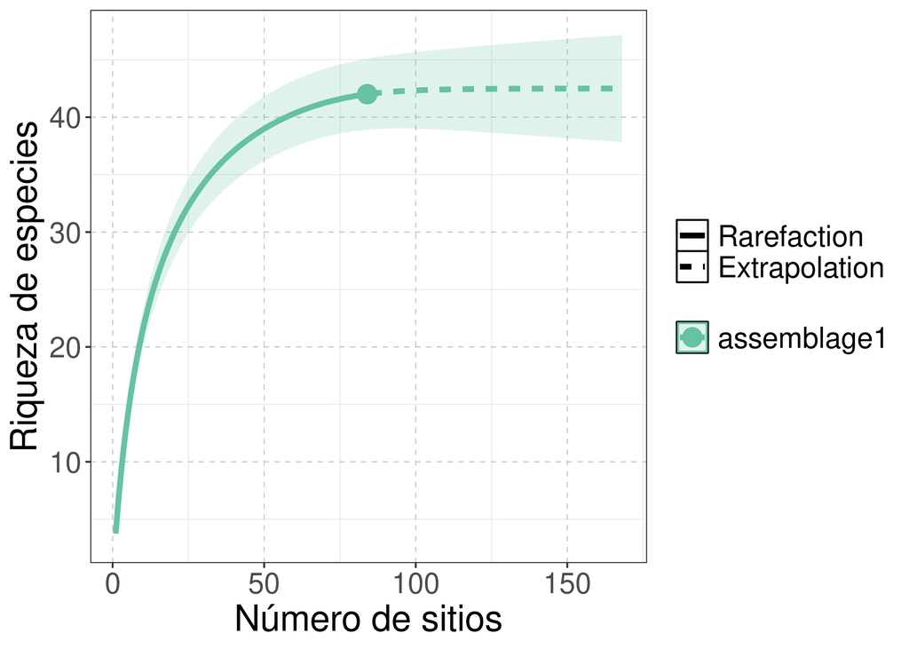

```r
mc_general <- mc %>%
  summarise_all(sum) %>%
  mutate(N = nrow(mc)) %>%
  relocate(N, .before = 1) %>%
  data.frame
nasin_raref <- iNEXT::iNEXT(
  x = t(mc_general),
  q=0,
  knots = 500,
  datatype = 'incidence_freq')
acumulacion_especies <- iNEXT::ggiNEXT(nasin_raref, type=1) +
  theme_bw() +
  theme(
    text = element_text(size = 20),
    panel.background = element_rect(fill = 'white', colour = 'black'),
    panel.grid.major = element_line(colour = "grey", linetype = "dashed", size = 0.25)
  ) +
  ylab('Riqueza de especies') +
  xlab('Número de sitios') +
  scale_y_continuous(breaks = seq(0, 80, length.out = 9)) +
  scale_color_manual(values = brewer.pal(8, 'Set2')) +
  scale_fill_manual(values = brewer.pal(8, 'Set2'))
acumulacion_especies
```

Ahora según los grupos previamente seleccionados en el análisis de agrupamiento.

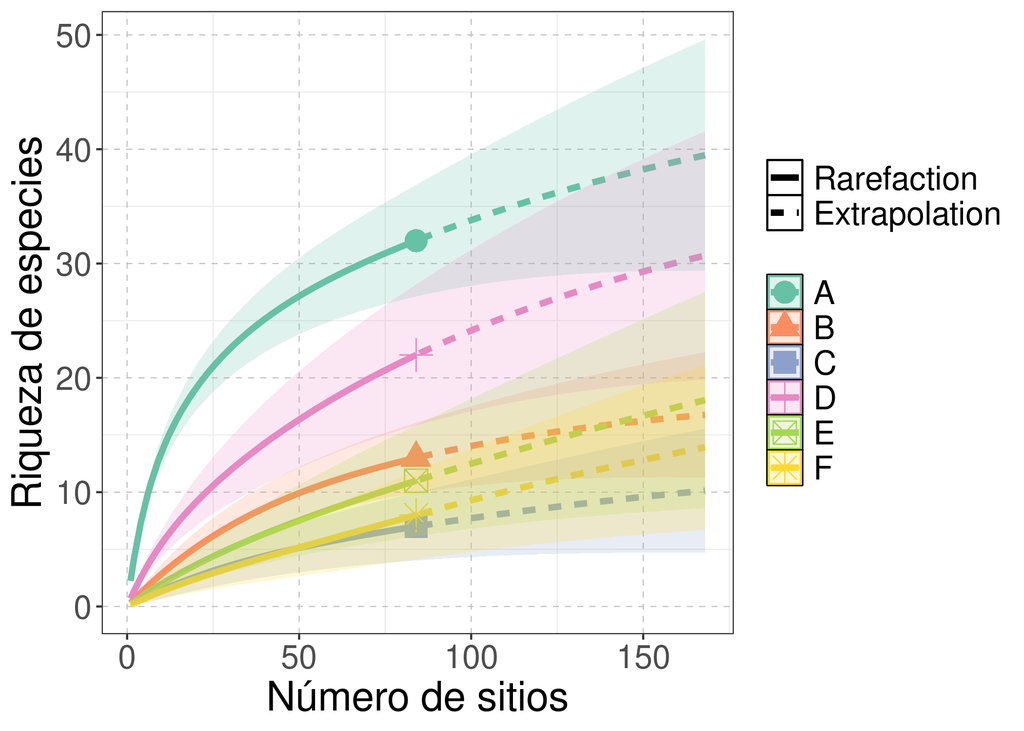

```r
grupos_seleccionados <- readRDS('grupos_seleccionados-Acanthaceae.RDS')
mc_grupos <- mc %>%
  mutate(g = grupos_seleccionados) %>%
  group_by(g) %>%
  summarise_all(sum) %>%
  # select(-g) %>%
  mutate(N = nrow(mc)) %>%
  relocate(N, .before = 1) %>%
  column_to_rownames('g') %>%
  data.frame
nasin_raref_general <- iNEXT::iNEXT(
  x = t(mc_grupos),
  q=0,
  knots = 100,
  datatype = 'incidence_freq')
acumulacion_especies_grupos <- iNEXT::ggiNEXT(nasin_raref_general, type=1) +
  theme_bw() +
  theme(
    text = element_text(size = 20),
    panel.background = element_rect(fill = 'white', colour = 'black'),
    panel.grid.major = element_line(colour = "grey", linetype = "dashed", size = 0.25)
  ) +
  ylab('Riqueza de especies') +
  xlab('Número de sitios') +
  scale_y_continuous(breaks = seq(0, 80, length.out = 9)) +
  scale_color_manual(values = brewer.pal(8, 'Set2')) +
  scale_fill_manual(values = brewer.pal(8, 'Set2'))
acumulacion_especies_grupos
```

## 4.4 Contribución de especies a la diversidad beta (SCBD, species contribution to beta diversity) y contribución local a la diversidad beta (LCBD local contribution to beta diversity)

```r
determinar_contrib_local_y_especie(
    mc = mc,
    alpha = 0.05,
    nperm = 9999,
    metodo = 'sorensen')
```

```
## $betadiv
## $beta
##    SStotal    BDtotal
## 35.8988229  0.4325159
##
## $SCBD
## [1] NA
##
## $LCBD
## 854cd4cbfffffff 854c8927fffffff 85672537fffffff 854c89abfffffff 854c8933fffffff
##     0.009697428     0.010291723     0.012253095     0.011478133     0.011329271
## 854c8997fffffff 854cf247fffffff 854cd29bfffffff 854cd477fffffff 854cd46bfffffff
##     0.009966884     0.009928355     0.013212778     0.010783233     0.014630352
## 854c89b3fffffff 854cd40bfffffff 854cf373fffffff 854cd423fffffff 854cc6c7fffffff
##     0.009905077     0.012154975     0.010616125     0.010718752     0.010946419
## 854c892ffffffff 854cd63bfffffff 854cd457fffffff 856725b7fffffff 854cf26ffffffff
##     0.011207715     0.015166471     0.013320538     0.011520482     0.008177134
## 854c89a3fffffff 854cd647fffffff 854cd453fffffff 854c89c7fffffff 854c89c3fffffff
##     0.009826747     0.010815226     0.011148645     0.012629357     0.014074487
## 854c8907fffffff 854cf347fffffff 854cd4bbfffffff 854cf24bfffffff 854cd0c3fffffff
##     0.014854105     0.011781145     0.013051028     0.010073083     0.013826622
## 854c897bfffffff 854cf31bfffffff 854cf243fffffff 854cd42ffffffff 854cf303fffffff
##     0.012965228     0.011510735     0.010802765     0.009568563     0.011177847
## 854cd5b3fffffff 854cc64ffffffff 854c893bfffffff 854cf267fffffff 854cf333fffffff
##     0.010915905     0.013150514     0.010672086     0.014633247     0.010650550
## 854cf26bfffffff 854cd427fffffff 854c894bfffffff 854cf20ffffffff 854cc6cffffffff
##     0.013251356     0.009725955     0.013610530     0.011655316     0.009523805
## 854cc603fffffff 854cc613fffffff 854cd513fffffff 854cd5b7fffffff 854cf353fffffff
##     0.011518578     0.009685490     0.011828635     0.011652702     0.012450914
## 854cd403fffffff 854cd093fffffff 854c89a7fffffff 854cd553fffffff 854cd09bfffffff
##     0.013643469     0.010314901     0.011066525     0.010815226     0.009311319
## 854cd653fffffff 854cd46ffffffff 854cd4d3fffffff 854cc657fffffff 854cd41bfffffff
##     0.012300146     0.013465209     0.011234242     0.012019983     0.009801281
## 854cd293fffffff 854cd667fffffff 854c898ffffffff 854cd2d7fffffff 854c89bbfffffff
##     0.011520660     0.013875120     0.010202106     0.012038801     0.013090162
## 854cd40ffffffff 854cc67bfffffff 854cd467fffffff 854cf323fffffff 854c89b7fffffff
##     0.011211105     0.014602717     0.011108646     0.010273312     0.013908421
## 854cd5cffffffff 854cd693fffffff 854cf343fffffff 854cd47bfffffff 854cd623fffffff
##     0.013918767     0.015161997     0.013694316     0.010710780     0.014886257
## 854cd473fffffff 854c890ffffffff 854cd4c3fffffff 854cc673fffffff 854cd66ffffffff
```

[output cut: 120 more lines]

```
## 854cd653fffffff 854cd46ffffffff 854cd4d3fffffff 854cc657fffffff 854cd41bfffffff
##               1               1               1               1               1
## 854cd293fffffff 854cd667fffffff 854c898ffffffff 854cd2d7fffffff 854c89bbfffffff
##               1               1               1               1               1
## 854cd40ffffffff 854cc67bfffffff 854cd467fffffff 854cf323fffffff 854c89b7fffffff
##               1               1               1               1               1
## 854cd5cffffffff 854cd693fffffff 854cf343fffffff 854cd47bfffffff 854cd623fffffff
##               1               1               1               1               1
## 854cd473fffffff 854c890ffffffff 854cd4c3fffffff 854cc673fffffff 854cd66ffffffff
##               1               1               1               1               1
## 854cd697fffffff 854cd6affffffff 854cd58bfffffff 854cd44bfffffff
##               1               1               1               1
##
## $sitios_contribuyen_betadiv_ajustado
## character(0)
```

# Referencias

Borcard, Daniel, François Gillet, y Pierre Legendre. 2018. *Numerical ecology with R*. Springer.

Martínez Batlle, José Ramón. 2020. «biogeografia-master/scripts-de-analisis-BCI: Long coding sessions». Zenodo. https://doi.org/10.5281/zenodo.4402362.